# CLIA Pancreas_Combined analysis_GL 08162023

library(swimplot) library(coxphf) library(grid) library(gtable) library(readr) library(mosaic) library(dplyr) library(survival) library(survminer) library(ggplot2) library(scales) library(coxphf) library(ggthemes) library(tidyverse) library(gtsummary) library(flextable) library(parameters) library(car) library(ComplexHeatmap)

#This analysis is based on CLIA Pancreas Cohort and Cecchini OP-19495 Yale cohort. We will run analysis based on ctDNA and/or CA 19-9 in pre-op, MRD and Surveillance window. MRD window is defined as 2-12 weeks post-surgery and the Surveillance window as 12 weeks post-op if no adjuvant chemotherapy was given and 4 weeks after the end of chemotherapy for patients that received adjuvant chemotherapy.

#ctDNA positivity by stage and window

```r
#Number of Pts at the MRD Window - percentage positivity by stage
rm(list=ls())
setwd("~/Downloads")
circ_data <- read.csv("CLIA Pancreas_GL.csv")
circ_data <- circ_data[circ_data$Include.analysis==TRUE,]
circ_data <- circ_data[circ_data$Surgery==1,]
circ_data <- circ_data[circ_data$Stage!="IV",]
circ_data <- subset(circ_data, !is.na(ctDNA.MRD.Window))
circ_datadf <- as.data.frame(circ_data)

total_mrd <- sum(!is.na(circ_data$ctDNA.MRD.Window))
print(total_mrd)
```

```
[1] 110
```

```r
circ_data$ctDNA.MRD.Window <- as.factor(circ_data$ctDNA.MRD.Window)
cont_table_mrd <- table(circ_data$Stage, circ_data$ctDNA.MRD.Window)
print(cont_table_mrd)
```

```
       0  1
  I   30  8
  II  35  9
  III 14 14
```

```r
#Number of Pts at the Surveillance Window - percentage positivity by stage
rm(list=ls())
setwd("~/Downloads")
circ_data <- read.csv("CLIA Pancreas_GL.csv")
circ_data <- circ_data[circ_data$Include.analysis==TRUE,]
circ_data <- circ_data[circ_data$Surgery==1,]
circ_data <- circ_data[circ_data$Stage!="IV",]
circ_data <- subset(circ_data, !is.na(ctDNA.Surveillance.Window))
circ_datadf <- as.data.frame(circ_data)

total_surv <- sum(!is.na(circ_data$ctDNA.Surveillance.Window))
print(total_surv)
```

```
[1] 156
```

```r
circ_data$ctDNA.Surveillance.Window <- as.factor(circ_data$ctDNA.Surveillance.Window)
cont_table_surv <- table(circ_data$Stage, circ_data$ctDNA.Surveillance.Window)
print(cont_table_surv)
```

```
       0  1
  I   45 12
  II  42 19
  III 23 15
```

```r
#Number of Pts with ctDNA anytime post-op - percentage positivity by stage
rm(list=ls())
setwd("~/Downloads")
circ_data <- read.csv("CLIA Pancreas_GL.csv")
circ_data <- circ_data[circ_data$Include.analysis==TRUE,]
circ_data <- circ_data[circ_data$Surgery==1,]
circ_data <- circ_data[circ_data$Stage!="IV",]
circ_data <- subset(circ_data, !is.na(ctDNA.postSx.anytime))
circ_datadf <- as.data.frame(circ_data)

total_anytime <- sum(!is.na(circ_data$ctDNA.postSx.anytime))
print(total_anytime)
```

```
[1] 244
```

```r
circ_data$ctDNA.postSx.anytime <- as.factor(circ_data$ctDNA.postSx.anytime)
cont_table_anytime <- table(circ_data$Stage, circ_data$ctDNA.postSx.anytime)
print(cont_table_anytime)
```

```
       0  1
  I   49 30
  II  57 45
  III 24 39
```

#Radiological Recurrence rates by stage and window

```r
#Number of Pts at the MRD Window - percentage of radiological recurrence by stage
rm(list=ls())
setwd("~/Downloads")
circ_data <- read.csv("CLIA Pancreas_GL.csv")
circ_data <- circ_data[circ_data$Include.analysis==TRUE,]
circ_data <- circ_data[circ_data$Surgery==1,]
circ_data <- circ_data[circ_data$Stage!="IV",]
circ_data <- subset(circ_data, !is.na(ctDNA.MRD.Window))
circ_datadf <- as.data.frame(circ_data)

total_mrd <- sum(!is.na(circ_data$Radiological.Recurrence))
print(total_mrd)
```

```
[1] 110
```

```r
circ_data$Radiological.Recurrence <- as.factor(circ_data$Radiological.Recurrence)
cont_table_mrd <- table(circ_data$Stage, circ_data$Radiological.Recurrence)
print(cont_table_mrd)
```

```
      FALSE TRUE
  I      19   19
  II     28   16
  III    17   11
```

```r
#Number of Pts at the Surveillance Window - percentage of radiological recurrence by stage
rm(list=ls())
setwd("~/Downloads")
circ_data <- read.csv("CLIA Pancreas_GL.csv")
circ_data <- circ_data[circ_data$Include.analysis==TRUE,]
circ_data <- circ_data[circ_data$Surgery==1,]
circ_data <- circ_data[circ_data$Stage!="IV",]
circ_data <- subset(circ_data, !is.na(ctDNA.Surveillance.Window))
circ_datadf <- as.data.frame(circ_data)

total_surv <- sum(!is.na(circ_data$Radiological.Recurrence))
print(total_surv)
```

```
[1] 156
```

```r
circ_data$Radiological.Recurrence <- as.factor(circ_data$Radiological.Recurrence)
cont_table_surv <- table(circ_data$Stage, circ_data$Radiological.Recurrence)
print(cont_table_surv)
```

```
      FALSE TRUE
  I      39   18
  II     37   24
  III    21   17
```

```r
#We run Fisher's exact test for recurrence rates in Stage II vs III in the surveillance window
rm(list=ls())
setwd("~/Downloads")
circ_data <- read.csv("CLIA Pancreas_GL.csv")
circ_data <- circ_data[circ_data$Include.analysis==TRUE,]
circ_data <- circ_data[circ_data$Surgery==1,]
circ_data <- circ_data[circ_data$Stage!="I",]
circ_data <- circ_data[circ_data$Stage!="IV",]
circ_data <- subset(circ_data, !is.na(ctDNA.Surveillance.Window))
circ_datadf <- as.data.frame(circ_data)

circ_data$Stage <- factor(circ_data$Stage, levels = c("II", "III"), labels = c("II", "III"))
circ_data$Radiological.Recurrence <- factor(circ_data$Radiological.Recurrence, levels = c("FALSE", "TRUE"), labels = c("No Recurrence", "Recurrence"))
contingency_table <- table(circ_data$Stage, circ_data$Radiological.Recurrence)
chi_square_test <- chisq.test(contingency_table)
print(chi_square_test)
```

```
    Pearson's Chi-squared test with Yates' continuity correction

data:  contingency_table
X-squared = 0.10238, df = 1, p-value = 0.749
```

```r
fisher_exact_test <- fisher.test(contingency_table)
print(fisher_exact_test)
```

```
    Fisher's Exact Test for Count Data

data:  contingency_table
p-value = 0.6764
alternative hypothesis: true odds ratio is not equal to 1
95 percent confidence interval:
 0.5055338 3.0615479
sample estimates:
odds ratio
  1.245196
```

```r
print(contingency_table)
```

```
      No Recurrence Recurrence
  II             37         24
  III            21         17
```

```r
#Number of Pts with ctDNA anytime post-op - percentage of radiological recurrence by stage
rm(list=ls())
setwd("~/Downloads")
circ_data <- read.csv("CLIA Pancreas_GL.csv")
circ_data <- circ_data[circ_data$Include.analysis==TRUE,]
circ_data <- circ_data[circ_data$Surgery==1,]
circ_data <- circ_data[circ_data$Stage!="IV",]
circ_data <- subset(circ_data, !is.na(ctDNA.postSx.anytime))
circ_datadf <- as.data.frame(circ_data)

total_anytime <- sum(!is.na(circ_data$Radiological.Recurrence))
print(total_anytime)
```

```
[1] 244
```

```r
circ_data$Radiological.Recurrence <- as.factor(circ_data$Radiological.Recurrence)
cont_table_anytime <- table(circ_data$Stage, circ_data$Radiological.Recurrence)
print(cont_table_anytime)
```

```
      FALSE TRUE
  I      43   36
  II     56   46
  III    29   34
```

#Demographics Table

```r
rm(list=ls())
setwd("~/Downloads")
circ_data <- read.csv("CLIA Pancreas_GL.csv")
circ_data <- circ_data[circ_data$Include.analysis==TRUE,]
circ_datadf <- as.data.frame(circ_data)

circ_data_subset <- circ_data %>%
  select(
    Gender,
    Resectability.Group,
    Surgery,
    NAC,
    Stage,
    Grade,
    MSI,
    KRAS.Detailed,
    BRCA2.Detailed,
    Radiological.Recurrence,
    RecSite,
    DFS_months) %>%
  mutate(
    Gender = factor(Gender, levels = c("FEMALE", "MALE"), labels = c("Female", "Male")),
    Resectability.Group = factor(Resectability.Group, levels = c(1, 2), labels = c("Resectable", "Unresectable")),
    Surgery = factor(Surgery, levels = c(1, 0), labels = c("Yes", "No")),
    NAC = factor(NAC, levels = c("TRUE", "FALSE"), labels = c("Yes", "No")),
    Stage = factor(Stage, levels = c("I", "II", "III", "IV"), labels = c("I", "II", "III", "IV")),
    Grade = factor(Grade, levels = c(1, 2, 3), labels = c("G1", "G2", "G3")),
    MSI = factor(MSI),
    KRAS.Detailed = factor(KRAS.Detailed),
    BRCA2.Detailed = factor(BRCA2.Detailed),
    Radiological.Recurrence = factor(Radiological.Recurrence, levels = c("FALSE", "TRUE"), labels = c("No Recurrence", "Recurrence")),
    RecSite = factor(RecSite),
    DFS_months = as.numeric(DFS_months))
table1 <- circ_data_subset %>%
  tbl_summary(
    statistic = list(
      all_continuous() ~ "{median} ({min} - {max})",
      all_categorical() ~ "{n} ({p}%)"),
    label = list(
      Gender ~ "Gender",
      Resectability.Group ~ "Resectability",
      Surgery ~ "Surgery Performed",
      NAC ~ "Neoadjuvant Treatment",
      Stage ~ "Overall Stage",
      Grade ~ "Histological Grade",
      MSI ~ "MSI Status",
      KRAS.Detailed ~ "KRAS Status",
      BRCA2.Detailed ~ "BRCA2 Status",
      Radiological.Recurrence ~ "Radiological Recurrence",
      RecSite ~ "Recurrence Site",
      DFS_months ~ "Disease-Free Survival (months)"),) %>%
  bold_labels()
table1
```

| **Characteristic** | **N = 322**<sup>1</sup> |
| --- | --- |
| Gender |  |
| Female | 144 (45%) |
| Male | 178 (55%) |
| Resectability |  |
| Resectable | 281 (87%) |
| Unresectable | 41 (13%) |
| Surgery Performed | 271 (84%) |
| Neoadjuvant Treatment | 163 (51%) |
| Overall Stage |  |
| I | 87 (27%) |
| II | 119 (37%) |
| III | 73 (23%) |
| IV | 43 (13%) |
| Histological Grade |  |
| G1 | 25 (12%) |
| G2 | 131 (63%) |
| G3 | 51 (25%) |
| Unknown | 115 |
| MSI Status |  |
| MSI-Hi | 1 (0.3%) |
| MSS | 321 (100%) |
| KRAS Status |  |
|  | 88 (27%) |
| p.G12D | 87 (27%) |
| p.G12R | 46 (14%) |
| p.G12R, p.A11G | 1 (0.3%) |
| p.G12R, p.G12V | 1 (0.3%) |
| p.G12V | 79 (25%) |
| p.G13D | 2 (0.6%) |
| p.Q61H | 13 (4.0%) |
| p.Q61H, p.Q61L | 1 (0.3%) |
| p.Q61R | 3 (0.9%) |
| p.V14I, p.G12D | 1 (0.3%) |
| BRCA2 Status |  |
|  | 313 (97%) |
| p.C2212Vfs*17 | 1 (0.3%) |
| p.D2983* | 1 (0.3%) |
| p.E1250K | 1 (0.3%) |
| p.E621* | 1 (0.3%) |
| p.G637S, p.V1283Kfs*2 | 1 (0.3%) |
| p.K242Q | 1 (0.3%) |
| p.L3172F | 1 (0.3%) |
| p.T2722R | 1 (0.3%) |
| p.T3033Nfs*11 | 1 (0.3%) |
| Radiological Recurrence |  |
| No Recurrence | 148 (46%) |
| Recurrence | 174 (54%) |
| Recurrence Site |  |
|  | 195 (61%) |
| Bone | 1 (0.3%) |
| Liver | 47 (15%) |
| Liver, Brain | 1 (0.3%) |
| Liver, Kidney | 1 (0.3%) |
| Liver, Lung | 6 (1.9%) |
| Liver, Peritoneum | 1 (0.3%) |
| Local | 31 (9.6%) |
| Local, Bone | 2 (0.6%) |
| Local, Liver | 4 (1.2%) |
| Local, Lung | 6 (1.9%) |
| Local, Peritoneum | 1 (0.3%) |
| Lung | 12 (3.7%) |
| Lung, Bone | 1 (0.3%) |
| Lymph Node | 1 (0.3%) |
| Mediastinum | 1 (0.3%) |
| Pelvis | 1 (0.3%) |
| Peritoneum | 8 (2.5%) |
| Peritoneum, Bone | 1 (0.3%) |
| Peritoneum, Lung | 1 (0.3%) |
| Disease-Free Survival (months) | 14 (0 - 214) |
| Unknown | 51 |

<sup>1</sup> n (%); Median (Range)

```r
fit1 <- as_flex_table(
  table1,
  include = everything(),
  return_calls = FALSE,
  strip_md_bold = TRUE)
fit1
```

| Characteristic | N = 3221 |
| --- | --- |
| Gender |  |
| Female | 144 (45%) |
| Male | 178 (55%) |
| Resectability |  |
| Resectable | 281 (87%) |
| Unresectable | 41 (13%) |
| Surgery Performed | 271 (84%) |
| Neoadjuvant Treatment | 163 (51%) |
| Overall Stage |  |
| I | 87 (27%) |
| II | 119 (37%) |
| III | 73 (23%) |
| IV | 43 (13%) |
| Histological Grade |  |
| G1 | 25 (12%) |
| G2 | 131 (63%) |
| G3 | 51 (25%) |
| Unknown | 115 |
| MSI Status |  |
| MSI-Hi | 1 (0.3%) |
| MSS | 321 (100%) |
| KRAS Status |  |
|  | 88 (27%) |
| p.G12D | 87 (27%) |
| p.G12R | 46 (14%) |
| p.G12R, p.A11G | 1 (0.3%) |
| p.G12R, p.G12V | 1 (0.3%) |
| p.G12V | 79 (25%) |
| p.G13D | 2 (0.6%) |
| p.Q61H | 13 (4.0%) |
| p.Q61H, p.Q61L | 1 (0.3%) |
| p.Q61R | 3 (0.9%) |
| p.V14I, p.G12D | 1 (0.3%) |
| BRCA2 Status |  |
|  | 313 (97%) |
| p.C2212Vfs*17 | 1 (0.3%) |
| p.D2983* | 1 (0.3%) |
| p.E1250K | 1 (0.3%) |
| p.E621* | 1 (0.3%) |
| p.G637S, p.V1283Kfs*2 | 1 (0.3%) |
| p.K242Q | 1 (0.3%) |
| p.L3172F | 1 (0.3%) |
| p.T2722R | 1 (0.3%) |
| p.T3033Nfs*11 | 1 (0.3%) |
| Radiological Recurrence |  |
| No Recurrence | 148 (46%) |
| Recurrence | 174 (54%) |
| Recurrence Site |  |
|  | 195 (61%) |
| Bone | 1 (0.3%) |
| Liver | 47 (15%) |
| Liver, Brain | 1 (0.3%) |
| Liver, Kidney | 1 (0.3%) |
| Liver, Lung | 6 (1.9%) |
| Liver, Peritoneum | 1 (0.3%) |
| Local | 31 (9.6%) |
| Local, Bone | 2 (0.6%) |
| Local, Liver | 4 (1.2%) |
| Local, Lung | 6 (1.9%) |
| Local, Peritoneum | 1 (0.3%) |
| Lung | 12 (3.7%) |
| Lung, Bone | 1 (0.3%) |
| Lymph Node | 1 (0.3%) |
| Mediastinum | 1 (0.3%) |
| Pelvis | 1 (0.3%) |
| Peritoneum | 8 (2.5%) |
| Peritoneum, Bone | 1 (0.3%) |
| Peritoneum, Lung | 1 (0.3%) |
| Disease-Free Survival (months) | 14 (0 - 214) |
| Unknown | 51 |

1n (%); Median (Range)

```r
save_as_docx(fit1, path= "~/Downloads/table1.docx")
```

#Heatmap with Clinical & Genomics Factors

```r
rm(list=ls())
setwd("~/Downloads")
circ_data <- read.csv("CLIA Pancreas_GL.csv")
circ_data <- circ_data[circ_data$Include.analysis==TRUE,]
circ_data <- circ_data %>% arrange(Stage)
circ_datadf <- as.data.frame(circ_data)

ha <- HeatmapAnnotation(
  Stage = circ_data$Stage,
  Gender = circ_data$Gender,
  Surgery = circ_data$Surgery,
  NAC = circ_data$NAC,
  Grade = circ_data$Grade,
  MSI = circ_data$MSI,
  KRAS = circ_data$KRAS,
  BRCA2 = circ_data$BRCA2,
  ctDNA.MRD.Window = circ_data$ctDNA.MRD.Window,
  ctDNA.Surveillance.Window = circ_data$ctDNA.Surveillance.Window,
  ctDNA.anytime = circ_data$ctDNA.anytime,
  Radiological.Recurrence = circ_data$Radiological.Recurrence,

  col = list(Stage = c("I" = "seagreen1", "II" = "orange", "III" = "purple", "IV" = "brown2"),
    Gender = c("FEMALE" = "goldenrod" , "MALE" = "blue4"),
    Surgery = c("0" = "#C1211A", "1" ="#008BCE"),
    NAC = c("FALSE" = "cornflowerblue", "TRUE" ="darkmagenta"),
    Grade = c("0" = "grey", "1" = "coral", "2" ="darkgreen", "3" = "yellow3"),
    MSI = c("MSS" = "grey", "MSI-Hi" ="black"),
    KRAS = c("0" = "grey", "1" ="black"),
    BRCA2 = c("0" = "grey", "1" ="black"),
    ctDNA.MRD.Window = c("1" = "red3", "0" ="blue"),
    ctDNA.Surveillance.Window = c("1" = "red3", "0" ="blue"),
    ctDNA.anytime = c("1" = "red3", "0" ="blue"),
    Radiological.Recurrence = c("TRUE" = "red3", "FALSE" ="blue")
)
)
ht <- Heatmap(matrix(nrow = 0, ncol = length(circ_data$Stage)),show_row_names = FALSE,cluster_rows = F,cluster_columns = FALSE, top_annotation = ha)
pdf("heatmap.pdf",width = 7, height = 7)
draw(ht, annotation_legend_side = "bottom")
dev.off()
```

#Distribution of ctDNA

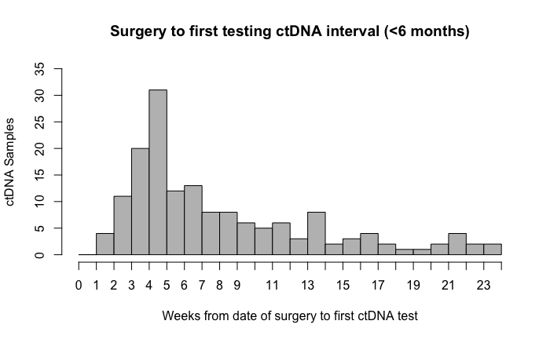

```r
rm(list=ls())
setwd("~/Downloads")
circ_data <- read.csv("CLIA Pancreas_GL.csv")
circ_data <- circ_data[circ_data$Include.analysis==TRUE,]
circ_data <- circ_data[circ_data$Surgery==1,]
circ_data <- circ_data[circ_data$Stage!=4,]
circ_data <- circ_data[circ_data$ctDNA.Surg.1<=24,]
circ_datadf <- as.data.frame(circ_data)

hist(circ_data$ctDNA.Surg.1,
     col='gray',
     main='Surgery to first testing ctDNA interval (<6 months)',
     xlab='Weeks from date of surgery to first ctDNA test',
     ylab='ctDNA Samples',
     ylim=c(0,35),
     breaks=seq(0,24,1), xaxp=c(0,24,24))
```

```r
filtered_data <- circ_data %>%
  filter(ctDNA.Surg.1 <= 24) %>%
  tally()
print(filtered_data)
```

| n |
| --- |
| 158 |

```r
filtered_data <- circ_data %>%
  filter(ctDNA.Surg.1 <= 2) %>%
  tally()
print(filtered_data)
```

| n |
| --- |
| 4 |

```r
filtered_data <- circ_data %>%
  filter(ctDNA.Surg.1 >2, ctDNA.Surg.1 <=4) %>%
  tally()
print(filtered_data)
```

| n |
| --- |
| 31 |

```r
filtered_data <- circ_data %>%
  filter(ctDNA.Surg.1 >4, ctDNA.Surg.1 <=8) %>%
  tally()
print(filtered_data)
```

| n |
| --- |
| 64 |

```r
filtered_data <- circ_data %>%
  filter(ctDNA.Surg.1 >8, ctDNA.Surg.1 <=12) %>%
  tally()
print(filtered_data)
```

| n |
| --- |
| 25 |

```r
filtered_data <- circ_data %>%
  filter(ctDNA.Surg.1 >12) %>%
  tally()
print(filtered_data)
```

| n |
| --- |
| 34 |

#DFS by ctDNA at the MRD window

```r
rm(list=ls())
setwd("~/Downloads")
circ_data <- read.csv("CLIA Pancreas_GL.csv")
circ_data <- circ_data[circ_data$Include.analysis==TRUE,]
circ_data <- circ_data[circ_data$Surgery==1,]
circ_data <- circ_data[circ_data$Stage!="IV",]
circ_data <- subset(circ_data, !is.na(ctDNA.MRD.Window))
circ_data$DFS_months[circ_data$DFS_months > 60] <- 60
circ_datadf <- as.data.frame(circ_data)

survfit(Surv(time = circ_data$DFS_months, event = circ_data$DFS.Event)~ctDNA.MRD.Window, data = circ_data)
```

```
Call: survfit(formula = Surv(time = circ_data$DFS_months, event = circ_data$DFS.Event) ~
    ctDNA.MRD.Window, data = circ_data)

                    n events median 0.95LCL 0.95UCL
ctDNA.MRD.Window=0 79     26  33.31   26.15      NA
ctDNA.MRD.Window=1 31     25   5.19    3.38    11.5
```

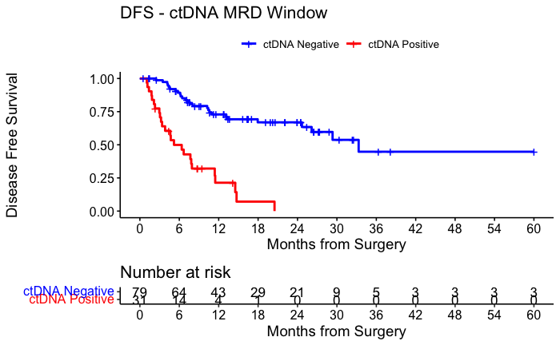

```r
surv_object <-Surv(time = circ_data$DFS_months, event = circ_data$DFS.Event)
KM_curve <- survfit(surv_object ~ ctDNA.MRD.Window, data = circ_data,conf.int=0.95,conf.type="log-log")
ggsurvplot(KM_curve, data = circ_data, pval = FALSE, conf.int = FALSE, risk.table = TRUE, break.time.by=6, palette=c("blue","red"), title="DFS - ctDNA MRD Window", ylab= "Disease Free Survival", xlab="Months from Surgery", legend.labs=c("ctDNA Negative", "ctDNA Positive"), legend.title="")
```

```r
summary(KM_curve, times= c(12, 24))
```

```
Call: survfit(formula = surv_object ~ ctDNA.MRD.Window, data = circ_data,
    conf.int = 0.95, conf.type = "log-log")

                ctDNA.MRD.Window=0
 time n.risk n.event survival std.err lower 95% CI upper 95% CI
   12     43      19    0.729  0.0535        0.608        0.818
   24     21       3    0.669  0.0594        0.539        0.771

                ctDNA.MRD.Window=1
        time       n.risk      n.event     survival      std.err lower 95% CI upper 95% CI
     12.0000       4.0000      22.0000       0.2138       0.0848       0.0779       0.3937
```

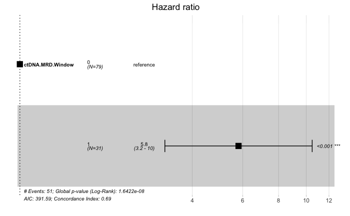

```r
circ_data$ctDNA.MRD.Window <- factor(circ_data$ctDNA.MRD.Window, levels=c("0","1"))
cox_fit <- coxph(surv_object ~ ctDNA.MRD.Window, data=circ_data)
ggforest(cox_fit,data = circ_data)
```

```r
summary(cox_fit)
```

```
Call:
coxph(formula = surv_object ~ ctDNA.MRD.Window, data = circ_data)

  n= 110, number of events= 51

                    coef exp(coef) se(coef)     z Pr(>|z|)
ctDNA.MRD.Window1 1.7577    5.7992   0.3021 5.818 5.94e-09 ***
---
Signif. codes:  0 ‘***’ 0.001 ‘**’ 0.01 ‘*’ 0.05 ‘.’ 0.1 ‘ ’ 1

                  exp(coef) exp(-coef) lower .95 upper .95
ctDNA.MRD.Window1     5.799     0.1724     3.208     10.48

Concordance= 0.686  (se = 0.031 )
Likelihood ratio test= 31.88  on 1 df,   p=2e-08
Wald test            = 33.85  on 1 df,   p=6e-09
Score (logrank) test = 42.54  on 1 df,   p=7e-11
```

```r
cox_fit_summary <- summary(cox_fit)

# Extract values for HR, 95% CI, and p-value
HR <- cox_fit_summary$coefficients[2]
lower_CI <- cox_fit_summary$conf.int[3]
upper_CI <- cox_fit_summary$conf.int[4]
p_value <- cox_fit_summary$coefficients[5]
label_text <- paste0("HR = ", round(HR, 2), " (", round(lower_CI, 2), "-", round(upper_CI, 2), "); p = ", round(p_value, 3))
print(label_text)
```

```
[1] "HR = 5.8 (3.21-10.48); p = 0"
```

#DFS by ctDNA and NAC combination - four groups

```r
rm(list=ls())
setwd("~/Downloads")
circ_data <- read.csv("CLIA Pancreas_GL.csv")
circ_data <- circ_data[circ_data$Include.analysis==TRUE,]
circ_data <- circ_data[circ_data$Surgery==1,]
circ_data <- circ_data[circ_data$Stage!="IV",]
circ_data$DFS_months[circ_data$DFS_months > 60] <- 60

circ_data$ctDNA.MRD.NAC <- NA #first we create the variable for the ctDNA & NAC combination, and we assign values
circ_data <- circ_data %>%
  mutate(ctDNA.MRD.NAC = case_when(
    NAC == 1 & ctDNA.MRD.Window == 0 ~ 1,
    NAC == 1 & ctDNA.MRD.Window == 1 ~ 2,
    NAC == 0 & ctDNA.MRD.Window == 0 ~ 3,
    NAC == 0 & ctDNA.MRD.Window == 1 ~ 4
  ))

survfit(Surv(time = circ_data$DFS_months, event = circ_data$DFS.Event)~ctDNA.MRD.NAC, data = circ_data)
```

```
Call: survfit(formula = Surv(time = circ_data$DFS_months, event = circ_data$DFS.Event) ~
    ctDNA.MRD.NAC, data = circ_data)

   149 observations deleted due to missingness
                 n events median 0.95LCL 0.95UCL
ctDNA.MRD.NAC=1 53     18  29.34   26.15      NA
ctDNA.MRD.NAC=2 14     13   5.78    4.63      NA
ctDNA.MRD.NAC=3 26      8     NA   13.14      NA
ctDNA.MRD.NAC=4 17     12   7.92    3.06      NA
```

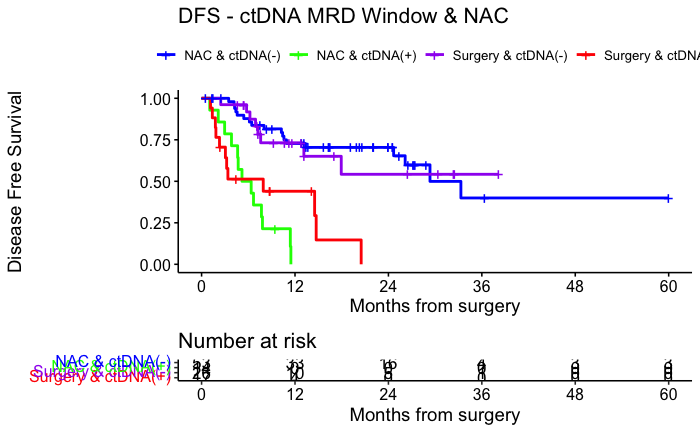

```r
surv_object <-Surv(time = circ_data$DFS_months, event = circ_data$DFS.Event)
KM_curve <- survfit(surv_object ~ ctDNA.MRD.NAC, data = circ_data,conf.int=0.95,conf.type="log-log")
ggsurvplot(KM_curve, data = circ_data, pval = FALSE, conf.int = FALSE, risk.table = TRUE, break.time.by=12, palette=c("blue","green","purple", "red"), title="DFS - ctDNA MRD Window & NAC", ylab= "Disease Free Survival", xlab="Months from surgery", legend.labs=c("NAC & ctDNA(-)", "NAC & ctDNA(+)","Surgery & ctDNA(-)", "Surgery & ctDNA(+)"), legend.title="")
```

```r
summary(KM_curve, ctDNA.MRD.NAC= c(0))
```

```
Call: survfit(formula = surv_object ~ ctDNA.MRD.NAC, data = circ_data,
    conf.int = 0.95, conf.type = "log-log")

149 observations deleted due to missingness
                ctDNA.MRD.NAC=1
  time n.risk n.event survival std.err lower 95% CI upper 95% CI
  3.48     49       1    0.980  0.0202        0.864        0.997
  4.17     48       1    0.959  0.0283        0.847        0.990
  4.24     47       1    0.939  0.0342        0.822        0.980
  4.40     46       1    0.918  0.0391        0.797        0.969
  4.57     45       1    0.898  0.0432        0.772        0.956
  5.42     44       1    0.878  0.0468        0.748        0.943
  6.14     43       1    0.857  0.0500        0.724        0.929
  6.44     42       1    0.837  0.0528        0.700        0.915
  8.02     40       1    0.816  0.0555        0.676        0.900
 10.25     37       1    0.794  0.0582        0.650        0.883
 10.41     36       1    0.772  0.0606        0.625        0.867
 10.58     35       1    0.750  0.0628        0.601        0.850
 10.91     34       1    0.728  0.0647        0.577        0.832
 13.34     31       1    0.704  0.0667        0.551        0.813
 24.67     14       1    0.654  0.0786        0.477        0.784
 26.15     12       1    0.599  0.0890        0.405        0.748
 29.34      6       1    0.499  0.1175        0.259        0.700
 33.31      5       1    0.400  0.1297        0.160        0.632

                ctDNA.MRD.NAC=2
  time n.risk n.event survival std.err lower 95% CI upper 95% CI
  1.05     14       1    0.929  0.0688      0.59077        0.990
  2.14     13       1    0.857  0.0935      0.53945        0.962
  2.96     12       1    0.786  0.1097      0.47246        0.925
  3.84     11       1    0.714  0.1207      0.40630        0.882
  4.63     10       1    0.643  0.1281      0.34331        0.833
  4.70      9       1    0.571  0.1323      0.28401        0.780
  5.19      8       1    0.500  0.1336      0.22859        0.722
  6.37      7       1    0.429  0.1323      0.17727        0.660
  6.67      6       1    0.357  0.1281      0.13035        0.594
  7.69      5       1    0.286  0.1207      0.08834        0.524
  7.82      4       1    0.214  0.1097      0.05212        0.448
 11.40      2       1    0.107  0.0935      0.00819        0.354
 11.47      1       1    0.000     NaN           NA           NA
```

[output cut: 11 more lines]

```

                ctDNA.MRD.NAC=4
  time n.risk n.event survival std.err lower 95% CI upper 95% CI
  1.15     17       1    0.941  0.0571      0.65018        0.991
  1.38     16       1    0.882  0.0781      0.60598        0.969
  1.77     15       1    0.824  0.0925      0.54713        0.939
  1.84     14       1    0.765  0.1029      0.48828        0.904
  2.30     13       1    0.706  0.1105      0.43148        0.866
  3.06     11       1    0.642  0.1176      0.36896        0.821
  3.22     10       1    0.578  0.1221      0.31101        0.773
  3.38      9       1    0.513  0.1243      0.25709        0.721
  7.92      7       1    0.440  0.1263      0.19610        0.661
 14.52      3       1    0.293  0.1464      0.06569        0.576
 14.72      2       1    0.147  0.1269      0.00961        0.452
 20.50      1       1    0.000     NaN           NA           NA
```

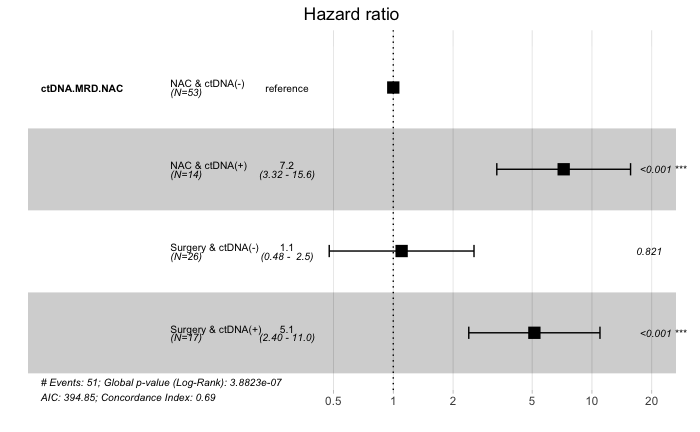

```r
circ_data$ctDNA.MRD.NAC <- factor(circ_data$ctDNA.MRD.NAC, levels=c("1","2", "3", "4"), labels = c("NAC & ctDNA(-)", "NAC & ctDNA(+)","Surgery & ctDNA(-)", "Surgery & ctDNA(+)"))
cox_fit <- coxph(surv_object ~ ctDNA.MRD.NAC, data=circ_data)
ggforest(cox_fit,data = circ_data)
```

```r
summary(cox_fit)
```

```
Call:
coxph(formula = surv_object ~ ctDNA.MRD.NAC, data = circ_data)

  n= 110, number of events= 51
   (149 observations deleted due to missingness)

                                   coef exp(coef) se(coef)     z Pr(>|z|)
ctDNA.MRD.NACNAC & ctDNA(+)     1.97501   7.20666  0.39548 4.994 5.92e-07 ***
ctDNA.MRD.NACSurgery & ctDNA(-) 0.09668   1.10151  0.42806 0.226    0.821
ctDNA.MRD.NACSurgery & ctDNA(+) 1.63537   5.13135  0.38792 4.216 2.49e-05 ***
---
Signif. codes:  0 ‘***’ 0.001 ‘**’ 0.01 ‘*’ 0.05 ‘.’ 0.1 ‘ ’ 1

                                exp(coef) exp(-coef) lower .95 upper .95
ctDNA.MRD.NACNAC & ctDNA(+)         7.207     0.1388     3.320    15.645
ctDNA.MRD.NACSurgery & ctDNA(-)     1.102     0.9078     0.476     2.549
ctDNA.MRD.NACSurgery & ctDNA(+)     5.131     0.1949     2.399    10.976

Concordance= 0.692  (se = 0.035 )
Likelihood ratio test= 32.62  on 3 df,   p=4e-07
Wald test            = 34.66  on 3 df,   p=1e-07
Score (logrank) test = 44.13  on 3 df,   p=1e-09
```

#DFS by ctDNA at the MRD window - Stage analysis

```r
#Analysis at Stage I
rm(list=ls())
setwd("~/Downloads")
circ_data <- read.csv("CLIA Pancreas_GL.csv")
circ_data <- circ_data[circ_data$Include.analysis==TRUE,]
circ_data <- circ_data[circ_data$Surgery==1,]
circ_data <- circ_data[circ_data$Stage=="I",]
circ_data$DFS_months[circ_data$DFS_months > 60] <- 60
circ_datadf <- as.data.frame(circ_data)

survfit(Surv(time = circ_data$DFS_months, event = circ_data$DFS.Event)~ctDNA.MRD.Window, data = circ_data)
```

```
Call: survfit(formula = Surv(time = circ_data$DFS_months, event = circ_data$DFS.Event) ~
    ctDNA.MRD.Window, data = circ_data)

   44 observations deleted due to missingness
                    n events median 0.95LCL 0.95UCL
ctDNA.MRD.Window=0 30     12  26.15   13.34      NA
ctDNA.MRD.Window=1  8      7   2.76    1.84      NA
```

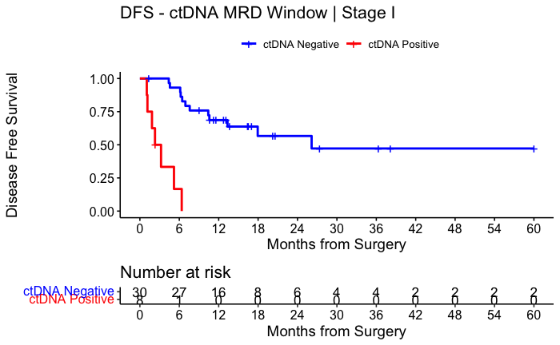

```r
surv_object <-Surv(time = circ_data$DFS_months, event = circ_data$DFS.Event)
KM_curve <- survfit(surv_object ~ ctDNA.MRD.Window, data = circ_data,conf.int=0.95,conf.type="log-log")
ggsurvplot(KM_curve, data = circ_data, pval = FALSE, conf.int = FALSE, risk.table = TRUE, break.time.by=6, palette=c("blue","red"), title="DFS - ctDNA MRD Window | Stage I", ylab= "Disease Free Survival", xlab="Months from Surgery", legend.labs=c("ctDNA Negative", "ctDNA Positive"), legend.title="")
```

```r
summary(KM_curve, times= c(6))
```

```
Call: survfit(formula = surv_object ~ ctDNA.MRD.Window, data = circ_data,
    conf.int = 0.95, conf.type = "log-log")

44 observations deleted due to missingness
                ctDNA.MRD.Window=0
        time       n.risk      n.event     survival      std.err lower 95% CI upper 95% CI
      6.0000      27.0000       2.0000       0.9310       0.0471       0.7514       0.9823

                ctDNA.MRD.Window=1
        time       n.risk      n.event     survival      std.err lower 95% CI upper 95% CI
     6.00000      1.00000      6.00000      0.16667      0.14829      0.00872      0.50814
```

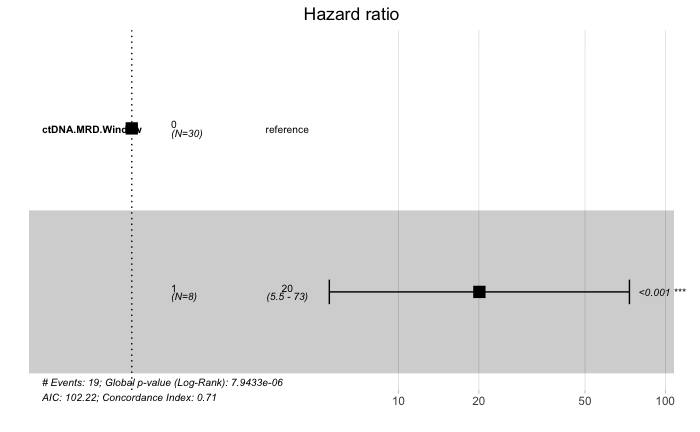

```r
circ_data$ctDNA.MRD.Window <- factor(circ_data$ctDNA.MRD.Window, levels=c("0","1"))
cox_fit <- coxph(surv_object ~ ctDNA.MRD.Window, data=circ_data)
ggforest(cox_fit,data = circ_data)
```

```r
summary(cox_fit)
```

```
Call:
coxph(formula = surv_object ~ ctDNA.MRD.Window, data = circ_data)

  n= 38, number of events= 19
   (44 observations deleted due to missingness)

                     coef exp(coef) se(coef)    z Pr(>|z|)
ctDNA.MRD.Window1  3.0001   20.0868   0.6608 4.54 5.62e-06 ***
---
Signif. codes:  0 ‘***’ 0.001 ‘**’ 0.01 ‘*’ 0.05 ‘.’ 0.1 ‘ ’ 1

                  exp(coef) exp(-coef) lower .95 upper .95
ctDNA.MRD.Window1     20.09    0.04978     5.501     73.34

Concordance= 0.705  (se = 0.047 )
Likelihood ratio test= 19.95  on 1 df,   p=8e-06
Wald test            = 20.61  on 1 df,   p=6e-06
Score (logrank) test = 35.75  on 1 df,   p=2e-09
```

```r
cox_fit_summary <- summary(cox_fit)

# Extract values for HR, 95% CI, and p-value
HR <- cox_fit_summary$coefficients[2]
lower_CI <- cox_fit_summary$conf.int[3]
upper_CI <- cox_fit_summary$conf.int[4]
p_value <- cox_fit_summary$coefficients[5]
label_text <- paste0("HR = ", round(HR, 2), " (", round(lower_CI, 2), "-", round(upper_CI, 2), "); p = ", round(p_value, 3))
print(label_text)
```

```
[1] "HR = 20.09 (5.5-73.34); p = 0"
```

```r
#Analysis at Stage II
rm(list=ls())
setwd("~/Downloads")
circ_data <- read.csv("CLIA Pancreas_GL.csv")
circ_data <- circ_data[circ_data$Include.analysis==TRUE,]
circ_data <- circ_data[circ_data$Surgery==1,]
circ_data <- circ_data[circ_data$Stage=="II",]
circ_data$DFS_months[circ_data$DFS_months > 60] <- 60
circ_datadf <- as.data.frame(circ_data)

survfit(Surv(time = circ_data$DFS_months, event = circ_data$DFS.Event)~ctDNA.MRD.Window, data = circ_data)
```

```
Call: survfit(formula = Surv(time = circ_data$DFS_months, event = circ_data$DFS.Event) ~
    ctDNA.MRD.Window, data = circ_data)

   67 observations deleted due to missingness
                    n events median 0.95LCL 0.95UCL
ctDNA.MRD.Window=0 35     12  33.31   24.67      NA
ctDNA.MRD.Window=1  9      8   4.63    2.96      NA
```

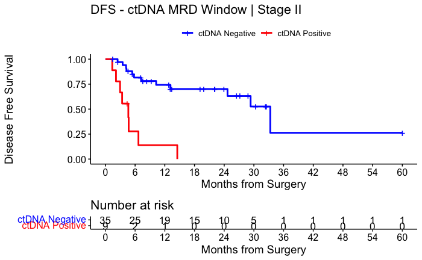

```r
surv_object <-Surv(time = circ_data$DFS_months, event = circ_data$DFS.Event)
KM_curve <- survfit(surv_object ~ ctDNA.MRD.Window, data = circ_data,conf.int=0.95,conf.type="log-log")
ggsurvplot(KM_curve, data = circ_data, pval = FALSE, conf.int = FALSE, risk.table = TRUE, break.time.by=6, palette=c("blue","red"), title="DFS - ctDNA MRD Window | Stage II", ylab= "Disease Free Survival", xlab="Months from Surgery", legend.labs=c("ctDNA Negative", "ctDNA Positive"), legend.title="")
```

```r
summary(KM_curve, times= c(12, 24))
```

```
Call: survfit(formula = surv_object ~ ctDNA.MRD.Window, data = circ_data,
    conf.int = 0.95, conf.type = "log-log")

67 observations deleted due to missingness
                ctDNA.MRD.Window=0
 time n.risk n.event survival std.err lower 95% CI upper 95% CI
   12     19       8    0.742  0.0794        0.548        0.863
   24     10       1    0.701  0.0850        0.500        0.834

                ctDNA.MRD.Window=1
        time       n.risk      n.event     survival      std.err lower 95% CI upper 95% CI
    12.00000      1.00000      7.00000      0.13889      0.12721      0.00744      0.45152
```

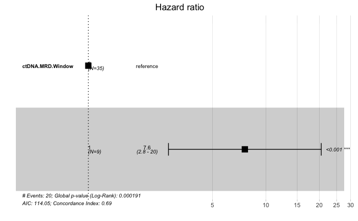

```r
circ_data$ctDNA.MRD.Window <- factor(circ_data$ctDNA.MRD.Window, levels=c("0","1"))
cox_fit <- coxph(surv_object ~ ctDNA.MRD.Window, data=circ_data)
ggforest(cox_fit,data = circ_data)
```

```r
summary(cox_fit)
```

```
Call:
coxph(formula = surv_object ~ ctDNA.MRD.Window, data = circ_data)

  n= 44, number of events= 20
   (67 observations deleted due to missingness)

                    coef exp(coef) se(coef)     z Pr(>|z|)
ctDNA.MRD.Window1 2.0295    7.6103   0.5052 4.017 5.89e-05 ***
---
Signif. codes:  0 ‘***’ 0.001 ‘**’ 0.01 ‘*’ 0.05 ‘.’ 0.1 ‘ ’ 1

                  exp(coef) exp(-coef) lower .95 upper .95
ctDNA.MRD.Window1      7.61     0.1314     2.827     20.48

Concordance= 0.686  (se = 0.052 )
Likelihood ratio test= 13.92  on 1 df,   p=2e-04
Wald test            = 16.14  on 1 df,   p=6e-05
Score (logrank) test = 21.69  on 1 df,   p=3e-06
```

```r
cox_fit_summary <- summary(cox_fit)

# Extract values for HR, 95% CI, and p-value
HR <- cox_fit_summary$coefficients[2]
lower_CI <- cox_fit_summary$conf.int[3]
upper_CI <- cox_fit_summary$conf.int[4]
p_value <- cox_fit_summary$coefficients[5]
label_text <- paste0("HR = ", round(HR, 2), " (", round(lower_CI, 2), "-", round(upper_CI, 2), "); p = ", round(p_value, 3))
print(label_text)
```

```
[1] "HR = 7.61 (2.83-20.48); p = 0"
```

```r
#Analysis at Stage III
rm(list=ls())
setwd("~/Downloads")
circ_data <- read.csv("CLIA Pancreas_GL.csv")
circ_data <- circ_data[circ_data$Include.analysis==TRUE,]
circ_data <- circ_data[circ_data$Surgery==1,]
circ_data <- circ_data[circ_data$Stage=="III",]
circ_datadf <- as.data.frame(circ_data)

survfit(Surv(time = circ_data$DFS_months, event = circ_data$DFS.Event)~ctDNA.MRD.Window, data = circ_data)
```

```
Call: survfit(formula = Surv(time = circ_data$DFS_months, event = circ_data$DFS.Event) ~
    ctDNA.MRD.Window, data = circ_data)

   38 observations deleted due to missingness
                    n events median 0.95LCL 0.95UCL
ctDNA.MRD.Window=0 14      2     NA      NA      NA
ctDNA.MRD.Window=1 14     10   11.4    7.82      NA
```

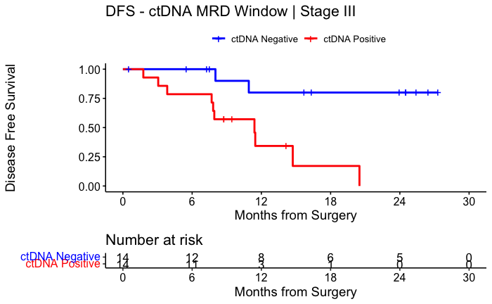

```r
surv_object <-Surv(time = circ_data$DFS_months, event = circ_data$DFS.Event)
KM_curve <- survfit(surv_object ~ ctDNA.MRD.Window, data = circ_data,conf.int=0.95,conf.type="log-log")
ggsurvplot(KM_curve, data = circ_data, pval = FALSE, conf.int = FALSE, risk.table = TRUE, break.time.by=6, palette=c("blue","red"), title="DFS - ctDNA MRD Window | Stage III", ylab= "Disease Free Survival", xlab="Months from Surgery", legend.labs=c("ctDNA Negative", "ctDNA Positive"), legend.title="")
```

```r
summary(KM_curve, times= c(12, 24))
```

```
Call: survfit(formula = surv_object ~ ctDNA.MRD.Window, data = circ_data,
    conf.int = 0.95, conf.type = "log-log")

38 observations deleted due to missingness
                ctDNA.MRD.Window=0
 time n.risk n.event survival std.err lower 95% CI upper 95% CI
   12      8       2      0.8   0.126        0.409        0.946
   24      5       0      0.8   0.126        0.409        0.946

                ctDNA.MRD.Window=1
        time       n.risk      n.event     survival      std.err lower 95% CI upper 95% CI
     12.0000       3.0000       8.0000       0.3429       0.1482       0.0942       0.6157
```

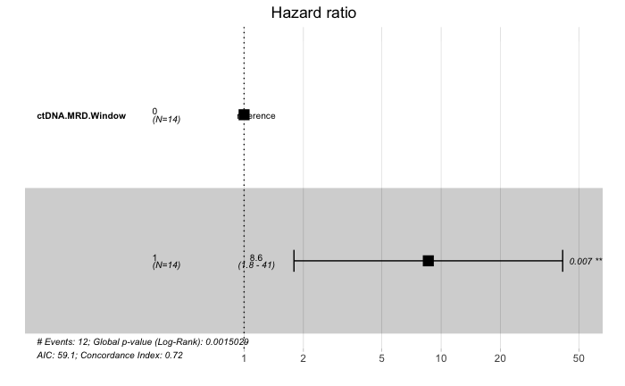

```r
circ_data$ctDNA.MRD.Window <- factor(circ_data$ctDNA.MRD.Window, levels=c("0","1"))
cox_fit <- coxph(surv_object ~ ctDNA.MRD.Window, data=circ_data)
ggforest(cox_fit,data = circ_data)
```

```r
summary(cox_fit)
```

```
Call:
coxph(formula = surv_object ~ ctDNA.MRD.Window, data = circ_data)

  n= 28, number of events= 12
   (38 observations deleted due to missingness)

                   coef exp(coef) se(coef)     z Pr(>|z|)
ctDNA.MRD.Window1 2.153     8.609    0.801 2.688  0.00719 **
---
Signif. codes:  0 ‘***’ 0.001 ‘**’ 0.01 ‘*’ 0.05 ‘.’ 0.1 ‘ ’ 1

                  exp(coef) exp(-coef) lower .95 upper .95
ctDNA.MRD.Window1     8.609     0.1162     1.791     41.37

Concordance= 0.715  (se = 0.057 )
Likelihood ratio test= 10.08  on 1 df,   p=0.002
Wald test            = 7.22  on 1 df,   p=0.007
Score (logrank) test = 9.73  on 1 df,   p=0.002
```

```r
cox_fit_summary <- summary(cox_fit)

# Extract values for HR, 95% CI, and p-value
HR <- cox_fit_summary$coefficients[2]
lower_CI <- cox_fit_summary$conf.int[3]
upper_CI <- cox_fit_summary$conf.int[4]
p_value <- cox_fit_summary$coefficients[5]
label_text <- paste0("HR = ", round(HR, 2), " (", round(lower_CI, 2), "-", round(upper_CI, 2), "); p = ", round(p_value, 3))
print(label_text)
```

```
[1] "HR = 8.61 (1.79-41.37); p = 0.007"
```

#DFS by ctDNA at the Surveillance window

```r
rm(list=ls())
setwd("~/Downloads")
circ_data <- read.csv("CLIA Pancreas_GL.csv")
circ_data <- circ_data[circ_data$Include.analysis==TRUE,]
circ_data <- circ_data[circ_data$Surgery==1,]
circ_data <- circ_data[circ_data$Stage!="IV",]
circ_data$DFS_months[circ_data$DFS_months > 60] <- 60
circ_datadf <- as.data.frame(circ_data)

survfit(Surv(time = circ_data$DFS_months, event = circ_data$DFS.Event)~ctDNA.Surveillance.Window, data = circ_data)
```

```
Call: survfit(formula = Surv(time = circ_data$DFS_months, event = circ_data$DFS.Event) ~
    ctDNA.Surveillance.Window, data = circ_data)

   103 observations deleted due to missingness
                              n events median 0.95LCL 0.95UCL
ctDNA.Surveillance.Window=0 110     17     NA      NA      NA
ctDNA.Surveillance.Window=1  46     43   11.4    10.2    14.5
```

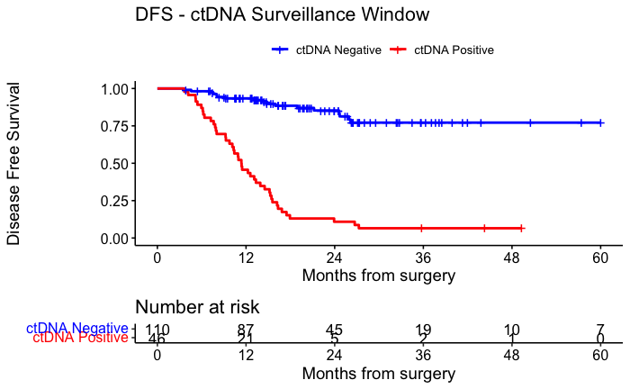

```r
surv_object <-Surv(time = circ_data$DFS_months, event = circ_data$DFS.Event)
KM_curve <- survfit(surv_object ~ ctDNA.Surveillance.Window, data = circ_data,conf.int=0.95,conf.type="log-log")
ggsurvplot(KM_curve, data = circ_data, pval = FALSE, conf.int = FALSE, risk.table = TRUE, break.time.by=12, palette=c("blue","red"), title="DFS - ctDNA Surveillance Window", ylab= "Disease Free Survival", xlab="Months from surgery", legend.labs=c("ctDNA Negative", "ctDNA Positive"), legend.title="")
```

```r
summary(KM_curve, ctDNA.Surveillance.Window= c(12, 24))
```

```
Call: survfit(formula = surv_object ~ ctDNA.Surveillance.Window, data = circ_data,
    conf.int = 0.95, conf.type = "log-log")

103 observations deleted due to missingness
                ctDNA.Surveillance.Window=0
  time n.risk n.event survival std.err lower 95% CI upper 95% CI
  3.48    110       1    0.991 0.00905        0.937        0.999
  4.57    108       1    0.982 0.01280        0.929        0.995
  7.36    104       1    0.972 0.01578        0.917        0.991
  7.59    102       1    0.963 0.01828        0.904        0.986
  8.02    101       1    0.953 0.02043        0.891        0.980
  8.05    100       1    0.944 0.02234        0.879        0.974
  9.20     97       1    0.934 0.02413        0.866        0.968
 13.14     84       1    0.923 0.02628        0.851        0.961
 14.32     75       1    0.911 0.02867        0.834        0.953
 14.85     72       1    0.898 0.03094        0.817        0.944
 15.97     68       1    0.885 0.03318        0.800        0.935
 18.92     61       1    0.870 0.03566        0.781        0.925
 21.19     51       1    0.853 0.03883        0.757        0.913
 24.58     43       1    0.833 0.04270        0.729        0.900
 24.67     42       1    0.813 0.04606        0.702        0.886
 25.92     39       1    0.793 0.04938        0.675        0.872
 26.15     38       1    0.772 0.05230        0.649        0.856

                ctDNA.Surveillance.Window=1
  time n.risk n.event survival std.err lower 95% CI upper 95% CI
  3.65     46       1   0.9783  0.0215       0.8555        0.997
  4.17     45       1   0.9565  0.0301       0.8371        0.989
  5.16     44       1   0.9348  0.0364       0.8113        0.978
  5.19     43       1   0.9130  0.0415       0.7847        0.966
  5.42     42       1   0.8913  0.0459       0.7584        0.953
  5.95     41       1   0.8696  0.0497       0.7325        0.939
  6.14     40       1   0.8478  0.0530       0.7071        0.924
  6.21     39       1   0.8261  0.0559       0.6822        0.909
  6.37     38       1   0.8043  0.0585       0.6577        0.893
  7.23     37       1   0.7826  0.0608       0.6336        0.877
  7.62     36       1   0.7609  0.0629       0.6099        0.860
  7.82     35       1   0.7391  0.0647       0.5866        0.843
  7.92     34       1   0.7174  0.0664       0.5636        0.825
  8.02     33       1   0.6957  0.0678       0.5409        0.807
```

[output cut: 14 more lines]

```
 13.34     18       1   0.3696  0.0712       0.2335        0.506
 13.93     17       1   0.3478  0.0702       0.2152        0.484
 14.52     16       1   0.3261  0.0691       0.1972        0.461
 15.18     15       1   0.3043  0.0678       0.1795        0.439
 15.28     14       1   0.2826  0.0664       0.1622        0.416
 15.44     13       1   0.2609  0.0647       0.1452        0.392
 15.57     12       1   0.2391  0.0629       0.1286        0.369
 16.20     11       1   0.2174  0.0608       0.1124        0.345
 16.33     10       1   0.1957  0.0585       0.0967        0.320
 16.85      9       1   0.1739  0.0559       0.0815        0.295
 17.48      8       1   0.1522  0.0530       0.0669        0.270
 17.94      7       1   0.1304  0.0497       0.0530        0.244
 23.92      6       1   0.1087  0.0459       0.0399        0.217
 26.71      5       1   0.0870  0.0415       0.0278        0.189
 27.27      4       1   0.0652  0.0364       0.0170        0.161
```

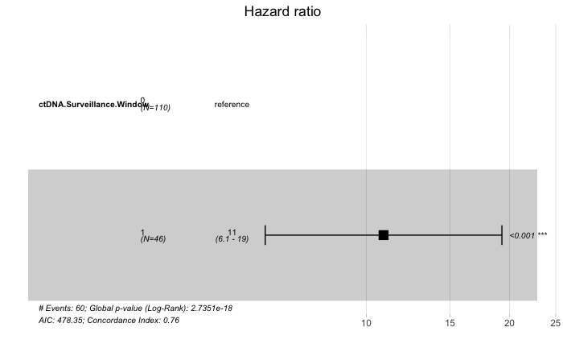

```r
circ_data$ctDNA.Surveillance.Window <- factor(circ_data$ctDNA.Surveillance.Window, levels=c("0","1"))
cox_fit <- coxph(surv_object ~ ctDNA.Surveillance.Window, data=circ_data)
ggforest(cox_fit,data = circ_data)
```

```r
summary(cox_fit)
```

```
Call:
coxph(formula = surv_object ~ ctDNA.Surveillance.Window, data = circ_data)

  n= 156, number of events= 60
   (103 observations deleted due to missingness)

                             coef exp(coef) se(coef)     z Pr(>|z|)
ctDNA.Surveillance.Window1  2.386    10.873    0.292 8.172 3.03e-16 ***
---
Signif. codes:  0 ‘***’ 0.001 ‘**’ 0.01 ‘*’ 0.05 ‘.’ 0.1 ‘ ’ 1

                           exp(coef) exp(-coef) lower .95 upper .95
ctDNA.Surveillance.Window1     10.87    0.09197     6.135     19.27

Concordance= 0.763  (se = 0.028 )
Likelihood ratio test= 76.07  on 1 df,   p=<2e-16
Wald test            = 66.78  on 1 df,   p=3e-16
Score (logrank) test = 100.5  on 1 df,   p=<2e-16
```

```r
cox_fit_summary <- summary(cox_fit)

# Extract values for HR, 95% CI, and p-value
HR <- cox_fit_summary$coefficients[2]
lower_CI <- cox_fit_summary$conf.int[3]
upper_CI <- cox_fit_summary$conf.int[4]
p_value <- cox_fit_summary$coefficients[5]
label_text <- paste0("HR = ", round(HR, 2), " (", round(lower_CI, 2), "-", round(upper_CI, 2), "); p = ", round(p_value, 3))
print(label_text)
```

```
[1] "HR = 10.87 (6.13-19.27); p = 0"
```

#DFS by ctDNA at the Surveillance window - Stage analysis

```r
#Analysis at Stage I
rm(list=ls())
setwd("~/Downloads")
circ_data <- read.csv("CLIA Pancreas_GL.csv")
circ_data <- circ_data[circ_data$Include.analysis==TRUE,]
circ_data <- circ_data[circ_data$Surgery==1,]
circ_data <- circ_data[circ_data$Stage=="I",]
circ_data$DFS_months[circ_data$DFS_months > 60] <- 60
circ_datadf <- as.data.frame(circ_data)

survfit(Surv(time = circ_data$DFS_months, event = circ_data$DFS.Event)~ctDNA.Surveillance.Window, data = circ_data)
```

```
Call: survfit(formula = Surv(time = circ_data$DFS_months, event = circ_data$DFS.Event) ~
    ctDNA.Surveillance.Window, data = circ_data)

   25 observations deleted due to missingness
                             n events median 0.95LCL 0.95UCL
ctDNA.Surveillance.Window=0 45      7     NA      NA      NA
ctDNA.Surveillance.Window=1 12     11   9.21    6.37      NA
```

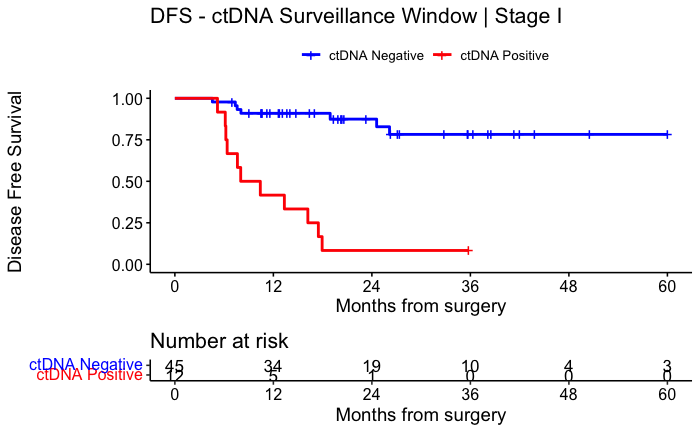

```r
surv_object <-Surv(time = circ_data$DFS_months, event = circ_data$DFS.Event)
KM_curve <- survfit(surv_object ~ ctDNA.Surveillance.Window, data = circ_data,conf.int=0.95,conf.type="log-log")
ggsurvplot(KM_curve, data = circ_data, pval = FALSE, conf.int = FALSE, risk.table = TRUE, break.time.by=12, palette=c("blue","red"), title="DFS - ctDNA Surveillance Window | Stage I", ylab= "Disease Free Survival", xlab="Months from surgery", legend.labs=c("ctDNA Negative", "ctDNA Positive"), legend.title="")
```

```r
summary(KM_curve, ctDNA.Surveillance.Window= c(12, 24))
```

```
Call: survfit(formula = surv_object ~ ctDNA.Surveillance.Window, data = circ_data,
    conf.int = 0.95, conf.type = "log-log")

25 observations deleted due to missingness
                ctDNA.Surveillance.Window=0
  time n.risk n.event survival std.err lower 95% CI upper 95% CI
  4.57     45       1    0.978  0.0220        0.853        0.997
  7.36     43       1    0.955  0.0311        0.832        0.989
  7.59     42       1    0.932  0.0377        0.805        0.978
  8.05     41       1    0.910  0.0431        0.777        0.965
 18.92     26       1    0.875  0.0538        0.719        0.947
 24.58     19       1    0.829  0.0679        0.643        0.923
 26.15     18       1    0.783  0.0782        0.580        0.896

                ctDNA.Surveillance.Window=1
  time n.risk n.event survival std.err lower 95% CI upper 95% CI
  5.19     12       1   0.9167  0.0798      0.53898        0.988
  6.14     11       1   0.8333  0.1076      0.48171        0.956
  6.21     10       1   0.7500  0.1250      0.40842        0.912
  6.37      9       1   0.6667  0.1361      0.33702        0.860
  7.62      8       1   0.5833  0.1423      0.27014        0.801
  8.02      7       1   0.5000  0.1443      0.20848        0.736
 10.41      6       1   0.4167  0.1423      0.15247        0.665
 13.34      5       1   0.3333  0.1361      0.10270        0.588
 16.20      4       1   0.2500  0.1250      0.06014        0.505
 17.48      3       1   0.1667  0.1076      0.02651        0.413
 17.94      2       1   0.0833  0.0798      0.00505        0.311
```

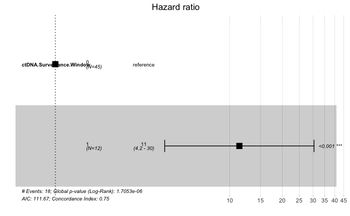

```r
circ_data$ctDNA.Surveillance.Window <- factor(circ_data$ctDNA.Surveillance.Window, levels=c("0","1"))
cox_fit <- coxph(surv_object ~ ctDNA.Surveillance.Window, data=circ_data)
ggforest(cox_fit,data = circ_data)
```

```r
summary(cox_fit)
```

```
Call:
coxph(formula = surv_object ~ ctDNA.Surveillance.Window, data = circ_data)

  n= 57, number of events= 18
   (25 observations deleted due to missingness)

                              coef exp(coef) se(coef)     z Pr(>|z|)
ctDNA.Surveillance.Window1  2.4291   11.3489   0.5027 4.832 1.35e-06 ***
---
Signif. codes:  0 ‘***’ 0.001 ‘**’ 0.01 ‘*’ 0.05 ‘.’ 0.1 ‘ ’ 1

                           exp(coef) exp(-coef) lower .95 upper .95
ctDNA.Surveillance.Window1     11.35    0.08811     4.237      30.4

Concordance= 0.751  (se = 0.053 )
Likelihood ratio test= 22.9  on 1 df,   p=2e-06
Wald test            = 23.35  on 1 df,   p=1e-06
Score (logrank) test = 35.49  on 1 df,   p=3e-09
```

```r
cox_fit_summary <- summary(cox_fit)

# Extract values for HR, 95% CI, and p-value
HR <- cox_fit_summary$coefficients[2]
lower_CI <- cox_fit_summary$conf.int[3]
upper_CI <- cox_fit_summary$conf.int[4]
p_value <- cox_fit_summary$coefficients[5]
label_text <- paste0("HR = ", round(HR, 2), " (", round(lower_CI, 2), "-", round(upper_CI, 2), "); p = ", round(p_value, 3))
print(label_text)
```

```
[1] "HR = 11.35 (4.24-30.4); p = 0"
```

```r
#Analysis at Stage II
rm(list=ls())
setwd("~/Downloads")
circ_data <- read.csv("CLIA Pancreas_GL.csv")
circ_data <- circ_data[circ_data$Include.analysis==TRUE,]
circ_data <- circ_data[circ_data$Surgery==1,]
circ_data <- circ_data[circ_data$Stage=="II",]
circ_data$DFS_months[circ_data$DFS_months > 60] <- 60
circ_datadf <- as.data.frame(circ_data)

survfit(Surv(time = circ_data$DFS_months, event = circ_data$DFS.Event)~ctDNA.Surveillance.Window, data = circ_data)
```

```
Call: survfit(formula = Surv(time = circ_data$DFS_months, event = circ_data$DFS.Event) ~
    ctDNA.Surveillance.Window, data = circ_data)

   50 observations deleted due to missingness
                             n events median 0.95LCL 0.95UCL
ctDNA.Surveillance.Window=0 42      7     NA      NA      NA
ctDNA.Surveillance.Window=1 19     17   12.2    10.3    26.7
```

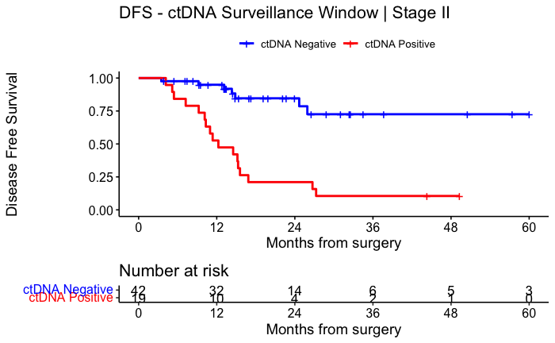

```r
surv_object <-Surv(time = circ_data$DFS_months, event = circ_data$DFS.Event)
KM_curve <- survfit(surv_object ~ ctDNA.Surveillance.Window, data = circ_data,conf.int=0.95,conf.type="log-log")
ggsurvplot(KM_curve, data = circ_data, pval = FALSE, conf.int = FALSE, risk.table = TRUE, break.time.by=12, palette=c("blue","red"), title="DFS - ctDNA Surveillance Window | Stage II", ylab= "Disease Free Survival", xlab="Months from surgery", legend.labs=c("ctDNA Negative", "ctDNA Positive"), legend.title="")
```

```r
summary(KM_curve, ctDNA.Surveillance.Window= c(12, 24))
```

```
Call: survfit(formula = surv_object ~ ctDNA.Surveillance.Window, data = circ_data,
    conf.int = 0.95, conf.type = "log-log")

50 observations deleted due to missingness
                ctDNA.Surveillance.Window=0
  time n.risk n.event survival std.err lower 95% CI upper 95% CI
  3.48     42       1    0.976  0.0235        0.843        0.997
  9.20     36       1    0.949  0.0352        0.811        0.987
 13.14     31       1    0.918  0.0455        0.766        0.973
 14.32     26       1    0.883  0.0558        0.714        0.955
 14.85     24       1    0.846  0.0645        0.665        0.934
 24.67     14       1    0.786  0.0835        0.564        0.903
 25.92     13       1    0.725  0.0965        0.485        0.867

                ctDNA.Surveillance.Window=1
  time n.risk n.event survival std.err lower 95% CI upper 95% CI
  4.17     19       1    0.947  0.0512       0.6812        0.992
  5.16     18       1    0.895  0.0704       0.6408        0.973
  5.42     17       1    0.842  0.0837       0.5865        0.946
  7.23     16       1    0.789  0.0935       0.5319        0.915
  9.23     15       1    0.737  0.1010       0.4789        0.881
 10.15     14       1    0.684  0.1066       0.4279        0.844
 10.32     13       1    0.632  0.1107       0.3790        0.804
 10.97     12       1    0.579  0.1133       0.3321        0.763
 11.37     11       1    0.526  0.1145       0.2872        0.719
 12.25     10       1    0.474  0.1145       0.2444        0.673
 14.52      9       1    0.421  0.1133       0.2037        0.625
 15.18      8       1    0.368  0.1107       0.1652        0.575
 15.28      7       1    0.316  0.1066       0.1291        0.522
 15.57      6       1    0.263  0.1010       0.0958        0.468
 16.85      5       1    0.211  0.0935       0.0656        0.410
 26.71      4       1    0.158  0.0837       0.0392        0.349
 27.27      3       1    0.105  0.0704       0.0178        0.284
```

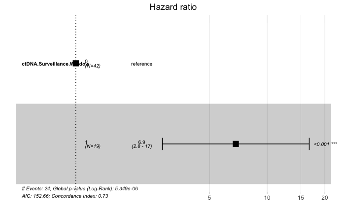

```r
circ_data$ctDNA.Surveillance.Window <- factor(circ_data$ctDNA.Surveillance.Window, levels=c("0","1"))
cox_fit <- coxph(surv_object ~ ctDNA.Surveillance.Window, data=circ_data)
ggforest(cox_fit,data = circ_data)
```

```r
summary(cox_fit)
```

```
Call:
coxph(formula = surv_object ~ ctDNA.Surveillance.Window, data = circ_data)

  n= 61, number of events= 24
   (50 observations deleted due to missingness)

                             coef exp(coef) se(coef)     z Pr(>|z|)
ctDNA.Surveillance.Window1 1.9251    6.8557   0.4506 4.272 1.94e-05 ***
---
Signif. codes:  0 ‘***’ 0.001 ‘**’ 0.01 ‘*’ 0.05 ‘.’ 0.1 ‘ ’ 1

                           exp(coef) exp(-coef) lower .95 upper .95
ctDNA.Surveillance.Window1     6.856     0.1459     2.834     16.58

Concordance= 0.732  (se = 0.048 )
Likelihood ratio test= 20.71  on 1 df,   p=5e-06
Wald test            = 18.25  on 1 df,   p=2e-05
Score (logrank) test = 24.47  on 1 df,   p=8e-07
```

```r
cox_fit_summary <- summary(cox_fit)

# Extract values for HR, 95% CI, and p-value
HR <- cox_fit_summary$coefficients[2]
lower_CI <- cox_fit_summary$conf.int[3]
upper_CI <- cox_fit_summary$conf.int[4]
p_value <- cox_fit_summary$coefficients[5]
label_text <- paste0("HR = ", round(HR, 2), " (", round(lower_CI, 2), "-", round(upper_CI, 2), "); p = ", round(p_value, 3))
print(label_text)
```

```
[1] "HR = 6.86 (2.83-16.58); p = 0"
```

```r
#Analysis at Stage III
rm(list=ls())
setwd("~/Downloads")
circ_data <- read.csv("CLIA Pancreas_GL.csv")
circ_data <- circ_data[circ_data$Include.analysis==TRUE,]
circ_data <- circ_data[circ_data$Surgery==1,]
circ_data <- circ_data[circ_data$Stage=="III",]
circ_data$DFS_months[circ_data$DFS_months > 60] <- 60
circ_datadf <- as.data.frame(circ_data)

survfit(Surv(time = circ_data$DFS_months, event = circ_data$DFS.Event)~ctDNA.Surveillance.Window, data = circ_data)
```

```
Call: survfit(formula = Surv(time = circ_data$DFS_months, event = circ_data$DFS.Event) ~
    ctDNA.Surveillance.Window, data = circ_data)

   28 observations deleted due to missingness
                             n events median 0.95LCL 0.95UCL
ctDNA.Surveillance.Window=0 23      3     NA      NA      NA
ctDNA.Surveillance.Window=1 15     15   11.4    9.27    15.4
```

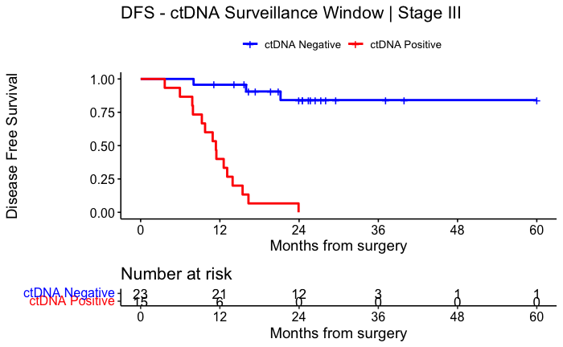

```r
surv_object <-Surv(time = circ_data$DFS_months, event = circ_data$DFS.Event)
KM_curve <- survfit(surv_object ~ ctDNA.Surveillance.Window, data = circ_data,conf.int=0.95,conf.type="log-log")
ggsurvplot(KM_curve, data = circ_data, pval = FALSE, conf.int = FALSE, risk.table = TRUE, break.time.by=12, palette=c("blue","red"), title="DFS - ctDNA Surveillance Window | Stage III", ylab= "Disease Free Survival", xlab="Months from surgery", legend.labs=c("ctDNA Negative", "ctDNA Positive"), legend.title="")
```

```r
summary(KM_curve, ctDNA.Surveillance.Window= c(12, 24))
```

```
Call: survfit(formula = surv_object ~ ctDNA.Surveillance.Window, data = circ_data,
    conf.int = 0.95, conf.type = "log-log")

28 observations deleted due to missingness
                ctDNA.Surveillance.Window=0
  time n.risk n.event survival std.err lower 95% CI upper 95% CI
  8.02     23       1    0.957  0.0425        0.729        0.994
 15.97     19       1    0.906  0.0634        0.673        0.976
 21.19     14       1    0.841  0.0858        0.577        0.947

                ctDNA.Surveillance.Window=1
  time n.risk n.event survival std.err lower 95% CI upper 95% CI
  3.65     15       1   0.9333  0.0644       0.6126        0.990
  5.95     14       1   0.8667  0.0878       0.5639        0.965
  7.82     13       1   0.8000  0.1033       0.4998        0.931
  7.92     12       1   0.7333  0.1142       0.4362        0.891
  9.27     11       1   0.6667  0.1217       0.3753        0.846
  9.76     10       1   0.6000  0.1265       0.3176        0.797
 10.91      9       1   0.5333  0.1288       0.2632        0.744
 11.40      8       1   0.4667  0.1288       0.2123        0.687
 11.47      7       1   0.4000  0.1265       0.1649        0.628
 12.58      6       1   0.3333  0.1217       0.1215        0.564
 13.11      5       1   0.2667  0.1142       0.0826        0.496
 13.93      4       1   0.2000  0.1033       0.0489        0.424
 15.44      3       1   0.1333  0.0878       0.0219        0.346
 16.33      2       1   0.0667  0.0644       0.0043        0.260
 23.92      1       1   0.0000     NaN           NA           NA
```

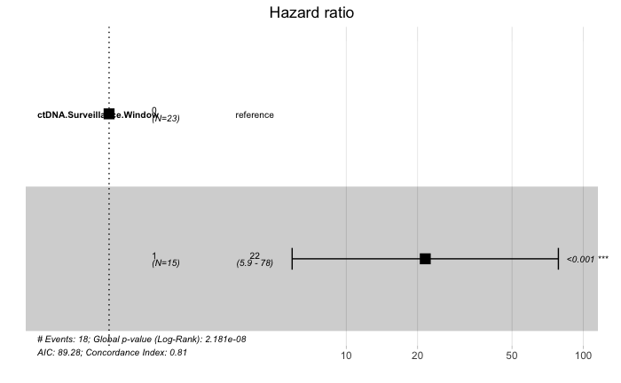

```r
circ_data$ctDNA.Surveillance.Window <- factor(circ_data$ctDNA.Surveillance.Window, levels=c("0","1"))
cox_fit <- coxph(surv_object ~ ctDNA.Surveillance.Window, data=circ_data)
ggforest(cox_fit,data = circ_data)
```

```r
summary(cox_fit)
```

```
Call:
coxph(formula = surv_object ~ ctDNA.Surveillance.Window, data = circ_data)

  n= 38, number of events= 18
   (28 observations deleted due to missingness)

                              coef exp(coef) se(coef)     z Pr(>|z|)
ctDNA.Surveillance.Window1  3.0700   21.5415   0.6594 4.656 3.23e-06 ***
---
Signif. codes:  0 ‘***’ 0.001 ‘**’ 0.01 ‘*’ 0.05 ‘.’ 0.1 ‘ ’ 1

                           exp(coef) exp(-coef) lower .95 upper .95
ctDNA.Surveillance.Window1     21.54    0.04642     5.915     78.45

Concordance= 0.809  (se = 0.039 )
Likelihood ratio test= 31.33  on 1 df,   p=2e-08
Wald test            = 21.67  on 1 df,   p=3e-06
Score (logrank) test = 37.41  on 1 df,   p=1e-09
```

```r
cox_fit_summary <- summary(cox_fit)

# Extract values for HR, 95% CI, and p-value
HR <- cox_fit_summary$coefficients[2]
lower_CI <- cox_fit_summary$conf.int[3]
upper_CI <- cox_fit_summary$conf.int[4]
p_value <- cox_fit_summary$coefficients[5]
label_text <- paste0("HR = ", round(HR, 2), " (", round(lower_CI, 2), "-", round(upper_CI, 2), "); p = ", round(p_value, 3))
print(label_text)
```

```
[1] "HR = 21.54 (5.92-78.45); p = 0"
```

#Multivariate regression for DFS at the Surveillance Window

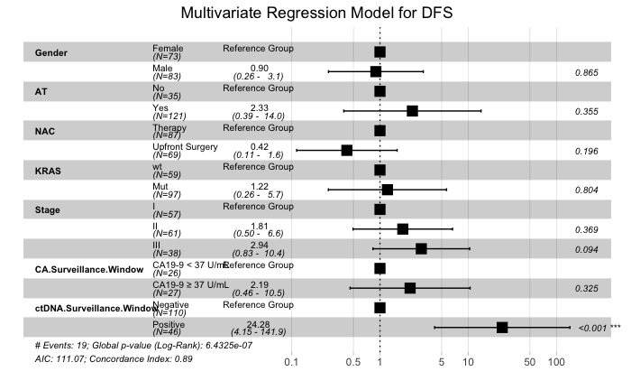

```r
rm(list=ls())
setwd("~/Downloads")
circ_data <- read.csv("CLIA Pancreas_GL.csv")
circ_data <- circ_data[circ_data$Include.analysis==TRUE,]
circ_data <- circ_data[circ_data$Surgery==1,]
circ_data <- circ_data[circ_data$Stage!="IV",]
circ_data <- subset(circ_data, !is.na(ctDNA.Surveillance.Window))
circ_datadf <- as.data.frame(circ_data)

circ_datadf$Gender <- factor(circ_datadf$Gender, levels = c("FEMALE", "MALE"), labels = c("Female", "Male"))
circ_datadf$AT <- factor(circ_datadf$AT, levels = c("0", "1"), labels = c("No", "Yes"))
circ_datadf$NAC <- factor(circ_datadf$NAC, levels = c("TRUE", "FALSE"), labels = c("Therapy", "Upfront Surgery"))
circ_datadf$KRAS <- factor(circ_datadf$KRAS, levels = c("0", "1"), labels = c("wt", "Mut"))
circ_datadf$Stage <- factor(circ_datadf$Stage, levels = c("I", "II", "III"), labels = c("I", "II", "III"))
circ_datadf$CA.Surveillance.Window <- factor(circ_datadf$CA.Surveillance.Window, levels = c("0", "1"), labels = c("CA19-9 < 37 U/mL", "CA19-9 ≥ 37 U/mL"))
circ_datadf$ctDNA.Surveillance.Window <- factor(circ_datadf$ctDNA.Surveillance.Window, levels=c("0","1"), labels = c("Negative", "Positive"))
surv_object<-Surv(time = circ_datadf$DFS_months, event = circ_datadf$DFS.Event)
cox_fit <- coxph(surv_object ~ Gender + AT + NAC + KRAS + Stage + CA.Surveillance.Window + ctDNA.Surveillance.Window, data=circ_datadf)
ggforest(cox_fit, data = circ_datadf, main = "Multivariate Regression Model for DFS", refLabel = "Reference Group")
```

```r
test.ph <- cox.zph(cox_fit)
```

#ctDNA Dynamics from MRD window to anytime

```r
rm(list=ls())
setwd("~/Downloads")
circ_data <- read.csv("CLIA Pancreas_GL.csv")
circ_data <- circ_data[circ_data$Include.analysis==TRUE,]
circ_data <- circ_data[circ_data$Surgery==1,]
circ_data <- circ_data[circ_data$Stage!="IV",]
circ_data$DFS_months=circ_data$DFS_months-3
circ_data <- circ_data[circ_data$DFS_months>=0,]
circ_data$DFS_months[circ_data$DFS_months > 60] <- 60
circ_data <- subset(circ_data, !is.na(ctDNA.Dynamics.anytime))
circ_datadf <- as.data.frame(circ_data)

survfit(Surv(time = circ_data$DFS_months, event = circ_data$DFS.Event)~ctDNA.Dynamics.anytime, data = circ_data)
```

```
Call: survfit(formula = Surv(time = circ_data$DFS_months, event = circ_data$DFS.Event) ~
    ctDNA.Dynamics.anytime, data = circ_data)

                          n events median 0.95LCL 0.95UCL
ctDNA.Dynamics.anytime=1 48      5     NA      NA      NA
ctDNA.Dynamics.anytime=2  2      1  11.72      NA      NA
ctDNA.Dynamics.anytime=3 19     18   5.02    3.21    21.7
ctDNA.Dynamics.anytime=4 13     12   4.69    2.19      NA
```

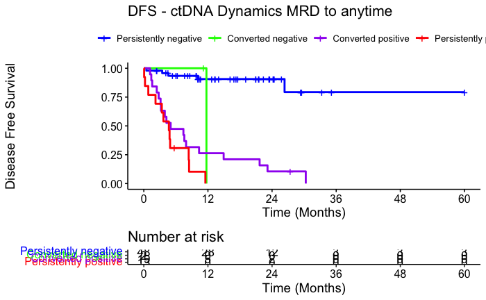

```r
surv_object <-Surv(time = circ_data$DFS_months, event = circ_data$DFS.Event)
KM_curve <- survfit(surv_object ~ ctDNA.Dynamics.anytime, data = circ_data,conf.int=0.95,conf.type="log-log")
ggsurvplot(KM_curve, data = circ_data, pval = FALSE, conf.int = FALSE, risk.table = TRUE, break.time.by=12, palette=c("blue","green","purple", "red"), title="DFS - ctDNA Dynamics MRD to anytime", ylab= "Disease Free Survival", xlab="Time (Months)", legend.labs=c("Persistently negative", "Converted negative","Converted positive", "Persistently positive"), legend.title="")
```

```r
summary(KM_curve, ctDNA.Dynamics.anytime= c(12))
```

```
Call: survfit(formula = surv_object ~ ctDNA.Dynamics.anytime, data = circ_data,
    conf.int = 0.95, conf.type = "log-log")

                ctDNA.Dynamics.anytime=1
  time n.risk n.event survival std.err lower 95% CI upper 95% CI
  0.48     48       1    0.979  0.0206        0.861        0.997
  3.44     45       1    0.957  0.0295        0.840        0.989
  4.59     42       1    0.935  0.0365        0.811        0.978
 10.14     33       1    0.906  0.0451        0.767        0.964
 26.34      8       1    0.793  0.1131        0.461        0.933

                ctDNA.Dynamics.anytime=2
        time       n.risk      n.event     survival      std.err lower 95% CI upper 95% CI
        11.7          1.0          1.0          0.0          NaN           NA           NA

                ctDNA.Dynamics.anytime=3
  time n.risk n.event survival std.err lower 95% CI upper 95% CI
  1.17     19       1    0.947  0.0512       0.6812        0.992
  1.40     18       1    0.895  0.0704       0.6408        0.973
  1.57     17       1    0.842  0.0837       0.5865        0.946
  2.42     16       1    0.789  0.0935       0.5319        0.915
  2.78     15       1    0.737  0.1010       0.4789        0.881
  3.14     14       1    0.684  0.1066       0.4279        0.844
  3.21     13       1    0.632  0.1107       0.3790        0.804
  3.93     12       1    0.579  0.1133       0.3321        0.763
  4.23     11       1    0.526  0.1145       0.2872        0.719
  5.02     10       1    0.474  0.1145       0.2444        0.673
  7.41      9       1    0.421  0.1133       0.2037        0.625
  7.58      8       1    0.368  0.1107       0.1652        0.575
  7.91      7       1    0.316  0.1066       0.1291        0.522
 10.34      6       1    0.263  0.1010       0.0958        0.468
 14.94      5       1    0.211  0.0935       0.0656        0.410
 21.67      4       1    0.158  0.0837       0.0392        0.349
 23.15      3       1    0.105  0.0704       0.0178        0.284
 30.31      1       1    0.000     NaN           NA           NA

                ctDNA.Dynamics.anytime=4
  time n.risk n.event survival std.err lower 95% CI upper 95% CI
  0.06     13       1    0.923  0.0739      0.56636        0.989
  0.22     12       1    0.846  0.1001      0.51220        0.959
  0.84     11       1    0.769  0.1169      0.44214        0.919
  2.19     10       1    0.692  0.1280      0.37336        0.872
  3.37      9       1    0.615  0.1349      0.30834        0.818
  3.67      8       1    0.538  0.1383      0.24766        0.760
  4.69      7       1    0.462  0.1383      0.19161        0.696
  4.82      6       1    0.385  0.1349      0.14054        0.628
  4.92      5       1    0.308  0.1280      0.09498        0.554
  8.40      3       1    0.205  0.1196      0.03845        0.463
  8.47      2       1    0.103  0.0940      0.00666        0.355
 11.52      1       1    0.000     NaN           NA           NA
```

```r
circ_data$ctDNA.Dynamics.anytime <- factor(circ_data$ctDNA.Dynamics.anytime, levels=c("1", "2", "3", "4"), labels = c("Persistently negative", "Converted negative", "Converted positive", "Persistently positive"))
cox_fit <- coxphf(surv_object ~ ctDNA.Dynamics.anytime, data=circ_data)
summary(cox_fit)
```

```
coxphf(formula = surv_object ~ ctDNA.Dynamics.anytime, data = circ_data)

Model fitted by Penalized ML
Confidence intervals and p-values by Profile Likelihood

                                                coef  se(coef) exp(coef) lower 0.95 upper 0.95     Chisq            p
ctDNA.Dynamics.anytimeConverted negative    1.997761 0.9583380  7.372527  0.7491336   37.65253  3.103023 7.814706e-02
ctDNA.Dynamics.anytimeConverted positive    2.616587 0.5006475 13.688922  5.6055235   39.45554 36.249334 1.736193e-09
ctDNA.Dynamics.anytimePersistently positive 3.166797 0.5519305 23.731346  8.6556156   74.08532 37.229618 1.050068e-09

Likelihood ratio test=55.92859 on 3 df, p=4.350964e-12, n=82
Wald test = 35.72427 on 3 df, p = 8.564028e-08

Covariance-Matrix:
                                            ctDNA.Dynamics.anytimeConverted negative ctDNA.Dynamics.anytimeConverted positive ctDNA.Dynamics.anytimePersistently positive
ctDNA.Dynamics.anytimeConverted negative                                   0.9184118                                0.1922785                                   0.2043042
ctDNA.Dynamics.anytimeConverted positive                                   0.1922785                                0.2506479                                   0.1974985
ctDNA.Dynamics.anytimePersistently positive                                0.2043042                                0.1974985                                   0.3046273
```

#DFS by ctDNA and ACT combination in NAC-treated pts - four groups

```r
rm(list=ls())
setwd("~/Downloads")
circ_data <- read.csv("CLIA Pancreas_GL.csv")
circ_data <- circ_data[circ_data$Include.analysis==TRUE,]
circ_data <- circ_data[circ_data$Surgery==1,]
circ_data <- circ_data[circ_data$Stage!="IV",]
circ_data <- circ_data[circ_data$NAC=="TRUE",]

circ_data$ctDNA.MRD.ACT <- NA #first we create the variable for the ctDNA & NAC combination, and we assign values
circ_data <- circ_data %>%
  mutate(ctDNA.MRD.ACT = case_when(
    AT == 1 & ctDNA.MRD.Window == 0 ~ 1,
    AT == 1 & ctDNA.MRD.Window == 1 ~ 3,
    AT == 0 & ctDNA.MRD.Window == 0 ~ 2,
    AT == 0 & ctDNA.MRD.Window == 1 ~ 4
  ))

circ_data <- subset(circ_data, !is.na(ctDNA.MRD.ACT))
circ_data$DFS_months[circ_data$DFS_months > 60] <- 60
survfit(Surv(time = circ_data$DFS_months, event = circ_data$DFS.Event)~ctDNA.MRD.ACT, data = circ_data)
```

```
Call: survfit(formula = Surv(time = circ_data$DFS_months, event = circ_data$DFS.Event) ~
    ctDNA.MRD.ACT, data = circ_data)

                 n events median 0.95LCL 0.95UCL
ctDNA.MRD.ACT=1 36     17  29.34   10.91      NA
ctDNA.MRD.ACT=2 17      1     NA      NA      NA
ctDNA.MRD.ACT=3 12     12   5.78    4.63      NA
ctDNA.MRD.ACT=4  2      1   2.96    2.96      NA
```

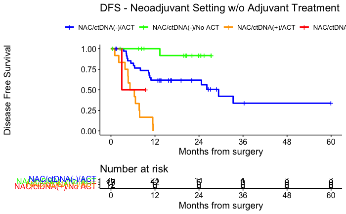

```r
surv_object <-Surv(time = circ_data$DFS_months, event = circ_data$DFS.Event)
KM_curve <- survfit(surv_object ~ ctDNA.MRD.ACT, data = circ_data,conf.int=0.95,conf.type="log-log")
ggsurvplot(KM_curve, data = circ_data, pval = FALSE, conf.int = FALSE, risk.table = TRUE, break.time.by=12, palette=c("blue","green","orange", "red"), title="DFS - Neoadjuvant Setting w/o Adjuvant Treatment", ylab= "Disease Free Survival", xlab="Months from surgery", legend.labs=c("NAC/ctDNA(-)/ACT", "NAC/ctDNA(-)/No ACT", "NAC/ctDNA(+)/ACT", "NAC/ctDNA(+)/No ACT"), legend.title="")
```

```r
summary(KM_curve, ctDNA.MRD.ACT= c(0))
```

```
Call: survfit(formula = surv_object ~ ctDNA.MRD.ACT, data = circ_data,
    conf.int = 0.95, conf.type = "log-log")

                ctDNA.MRD.ACT=1
  time n.risk n.event survival std.err lower 95% CI upper 95% CI
  3.48     34       1    0.971  0.0290        0.809        0.996
  4.17     33       1    0.941  0.0404        0.785        0.985
  4.24     32       1    0.912  0.0486        0.751        0.971
  4.40     31       1    0.882  0.0553        0.716        0.954
  4.57     30       1    0.853  0.0607        0.682        0.936
  5.42     29       1    0.824  0.0654        0.649        0.917
  6.14     28       1    0.794  0.0693        0.616        0.896
  6.44     27       1    0.765  0.0727        0.584        0.875
  8.02     26       1    0.735  0.0757        0.553        0.853
 10.25     25       1    0.706  0.0781        0.522        0.830
 10.41     24       1    0.676  0.0802        0.492        0.806
 10.58     23       1    0.647  0.0820        0.463        0.782
 10.91     22       1    0.618  0.0833        0.434        0.757
 24.67     11       1    0.561  0.0928        0.364        0.719
 26.15     10       1    0.505  0.0990        0.302        0.678
 29.34      6       1    0.421  0.1128        0.205        0.624
 33.31      5       1    0.337  0.1175        0.130        0.560

                ctDNA.MRD.ACT=2
        time       n.risk      n.event     survival      std.err lower 95% CI upper 95% CI
     13.3400      12.0000       1.0000       0.9167       0.0798       0.5390       0.9878

                ctDNA.MRD.ACT=3
  time n.risk n.event survival std.err lower 95% CI upper 95% CI
  1.05     12       1   0.9167  0.0798      0.53898        0.988
  2.14     11       1   0.8333  0.1076      0.48171        0.956
  3.84     10       1   0.7500  0.1250      0.40842        0.912
  4.63      9       1   0.6667  0.1361      0.33702        0.860
  4.70      8       1   0.5833  0.1423      0.27014        0.801
  5.19      7       1   0.5000  0.1443      0.20848        0.736
  6.37      6       1   0.4167  0.1423      0.15247        0.665
  6.67      5       1   0.3333  0.1361      0.10270        0.588
  7.69      4       1   0.2500  0.1250      0.06014        0.505
  7.82      3       1   0.1667  0.1076      0.02651        0.413
 11.40      2       1   0.0833  0.0798      0.00505        0.311
 11.47      1       1   0.0000     NaN           NA           NA

                ctDNA.MRD.ACT=4
        time       n.risk      n.event     survival      std.err lower 95% CI upper 95% CI
     2.96000      2.00000      1.00000      0.50000      0.35355      0.00598      0.91041
```

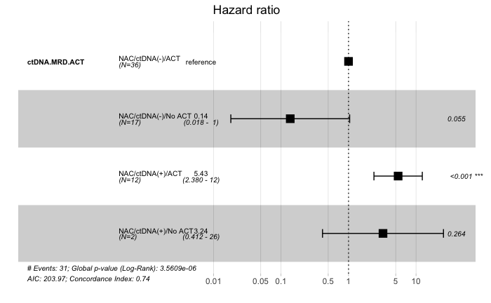

```r
circ_data$ctDNA.MRD.ACT <- factor(circ_data$ctDNA.MRD.ACT, levels=c("1","2","3","4"), labels = c("NAC/ctDNA(-)/ACT", "NAC/ctDNA(-)/No ACT", "NAC/ctDNA(+)/ACT", "NAC/ctDNA(+)/No ACT"))
cox_fit <- coxph(surv_object ~ ctDNA.MRD.ACT, data=circ_data)
ggforest(cox_fit,data = circ_data)
```

```r
summary(cox_fit)
```

```
Call:
coxph(formula = surv_object ~ ctDNA.MRD.ACT, data = circ_data)

  n= 67, number of events= 31

                                    coef exp(coef) se(coef)      z Pr(>|z|)
ctDNA.MRD.ACTNAC/ctDNA(-)/No ACT -1.9886    0.1369   1.0342 -1.923   0.0545 .
ctDNA.MRD.ACTNAC/ctDNA(+)/ACT     1.6917    5.4286   0.4208  4.020 5.82e-05 ***
ctDNA.MRD.ACTNAC/ctDNA(+)/No ACT  1.1757    3.2403   1.0528  1.117   0.2641
---
Signif. codes:  0 ‘***’ 0.001 ‘**’ 0.01 ‘*’ 0.05 ‘.’ 0.1 ‘ ’ 1

                                 exp(coef) exp(-coef) lower .95 upper .95
ctDNA.MRD.ACTNAC/ctDNA(-)/No ACT    0.1369     7.3055   0.01803     1.039
ctDNA.MRD.ACTNAC/ctDNA(+)/ACT       5.4286     0.1842   2.37958    12.384
ctDNA.MRD.ACTNAC/ctDNA(+)/No ACT    3.2403     0.3086   0.41156    25.512

Concordance= 0.744  (se = 0.033 )
Likelihood ratio test= 28.04  on 3 df,   p=4e-06
Wald test            = 23.04  on 3 df,   p=4e-05
Score (logrank) test = 35.54  on 3 df,   p=9e-08
```

#DFS by ctDNA and ACT combination in upfront surgery pts - four groups

```r
rm(list=ls())
setwd("~/Downloads")
circ_data <- read.csv("CLIA Pancreas_GL.csv")
circ_data <- circ_data[circ_data$Include.analysis==TRUE,]
circ_data <- circ_data[circ_data$Surgery==1,]
circ_data <- circ_data[circ_data$Stage!="IV",]
circ_data <- circ_data[circ_data$NAC=="FALSE",]

circ_data$ctDNA.MRD.ACT <- NA #first we create the variable for the ctDNA & NAC combination, and we assign values
circ_data <- circ_data %>%
  mutate(ctDNA.MRD.ACT = case_when(
    AT == 1 & ctDNA.MRD.Window == 0 ~ 1,
    AT == 1 & ctDNA.MRD.Window == 1 ~ 3,
    AT == 0 & ctDNA.MRD.Window == 0 ~ 2,
    AT == 0 & ctDNA.MRD.Window == 1 ~ 4
  ))

circ_data <- subset(circ_data, !is.na(ctDNA.MRD.ACT))
circ_data$DFS_months[circ_data$DFS_months > 60] <- 60
survfit(Surv(time = circ_data$DFS_months, event = circ_data$DFS.Event)~ctDNA.MRD.ACT, data = circ_data)
```

```
Call: survfit(formula = Surv(time = circ_data$DFS_months, event = circ_data$DFS.Event) ~
    ctDNA.MRD.ACT, data = circ_data)

                 n events median 0.95LCL 0.95UCL
ctDNA.MRD.ACT=1 22      8     NA   13.14      NA
ctDNA.MRD.ACT=2  4      0     NA      NA      NA
ctDNA.MRD.ACT=3 13      9   7.92    3.06      NA
ctDNA.MRD.ACT=4  4      3   8.51    1.84      NA
```

[figure not shown]

```r
surv_object <-Surv(time = circ_data$DFS_months, event = circ_data$DFS.Event)
KM_curve <- survfit(surv_object ~ ctDNA.MRD.ACT, data = circ_data,conf.int=0.95,conf.type="log-log")
ggsurvplot(KM_curve, data = circ_data, pval = FALSE, conf.int = FALSE, risk.table = TRUE, break.time.by=12, palette=c("blue","green","orange", "red"), title="DFS - Neoadjuvant Setting w/o Adjuvant Treatment", ylab= "Disease Free Survival", xlab="Months from surgery", legend.labs=c("Surgery/ctDNA(-)/ACT", "Surgery/ctDNA(-)/No ACT", "Surgery/ctDNA(+)/ACT", "Surgery/ctDNA(+)/No ACT"), legend.title="")
```

```r
summary(KM_curve, ctDNA.MRD.ACT= c(0))
```

```
Call: survfit(formula = surv_object ~ ctDNA.MRD.ACT, data = circ_data,
    conf.int = 0.95, conf.type = "log-log")

                ctDNA.MRD.ACT=1
  time n.risk n.event survival std.err lower 95% CI upper 95% CI
  2.46     22       1    0.955  0.0444        0.719        0.993
  5.78     19       1    0.904  0.0645        0.668        0.975
  6.21     18       1    0.854  0.0781        0.612        0.951
  6.93     17       1    0.804  0.0882        0.557        0.922
  7.23     15       1    0.750  0.0972        0.499        0.888
  7.59     12       1    0.688  0.1074        0.428        0.848
 13.14      9       1    0.611  0.1196        0.342        0.798
 17.94      6       1    0.509  0.1363        0.230        0.733

                ctDNA.MRD.ACT=2
     time n.risk n.event survival std.err lower 95% CI upper 95% CI

                ctDNA.MRD.ACT=3
  time n.risk n.event survival std.err lower 95% CI upper 95% CI
  1.15     13       1    0.923  0.0739       0.5664        0.989
  1.38     12       1    0.846  0.1001       0.5122        0.959
  1.77     11       1    0.769  0.1169       0.4421        0.919
  3.06      9       1    0.684  0.1315       0.3590        0.868
  3.22      8       1    0.598  0.1401       0.2850        0.810
  3.38      7       1    0.513  0.1438       0.2185        0.746
  7.92      5       1    0.410  0.1471       0.1407        0.667
 14.52      2       1    0.205  0.1626       0.0146        0.552
 20.50      1       1    0.000     NaN           NA           NA

                ctDNA.MRD.ACT=4
  time n.risk n.event survival std.err lower 95% CI upper 95% CI
  1.84      4       1     0.75   0.217       0.1279        0.961
  2.30      3       1     0.50   0.250       0.0578        0.845
 14.72      1       1     0.00     NaN           NA           NA
```

```r
circ_data$ctDNA.MRD.ACT <- factor(circ_data$ctDNA.MRD.ACT, levels=c("1","2","3","4"), labels = c("Surgery/ctDNA(-)/ACT", "Surgery/ctDNA(-)/No ACT", "Surgery/ctDNA(+)/ACT", "Surgery/ctDNA(+)/No ACT"))
cox_fit <- coxphf(surv_object ~ ctDNA.MRD.ACT, data=circ_data)
summary(cox_fit)
```

```
coxphf(formula = surv_object ~ ctDNA.MRD.ACT, data = circ_data)

Model fitted by Penalized ML
Confidence intervals and p-values by Profile Likelihood

                                          coef  se(coef) exp(coef)  lower 0.95 upper 0.95     Chisq          p
ctDNA.MRD.ACTSurgery/ctDNA(-)/No ACT -0.799554 1.5489343 0.4495294 0.003452292   3.741762 0.3766586 0.53939693
ctDNA.MRD.ACTSurgery/ctDNA(+)/ACT     1.195904 0.5019866 3.3065457 1.281524450   8.676063 6.0268722 0.01408968
ctDNA.MRD.ACTSurgery/ctDNA(+)/No ACT  1.296072 0.6805611 3.6549128 0.885949551  12.233182 3.2810609 0.07008361

Likelihood ratio test=9.129411 on 3 df, p=0.02761887, n=43
Wald test = 7.832561 on 3 df, p = 0.04960194

Covariance-Matrix:
                                     ctDNA.MRD.ACTSurgery/ctDNA(-)/No ACT ctDNA.MRD.ACTSurgery/ctDNA(+)/ACT ctDNA.MRD.ACTSurgery/ctDNA(+)/No ACT
ctDNA.MRD.ACTSurgery/ctDNA(-)/No ACT                            2.3991975                         0.1408433                            0.1437974
ctDNA.MRD.ACTSurgery/ctDNA(+)/ACT                               0.1408433                         0.2519905                            0.1368053
ctDNA.MRD.ACTSurgery/ctDNA(+)/No ACT                            0.1437974                         0.1368053                            0.4631635
```

#DFS by KRAS mutations

```r
rm(list=ls())
setwd("~/Downloads")
circ_data <- read.csv("CLIA Pancreas_GL.csv")
circ_data <- circ_data[circ_data$Include.analysis==TRUE,]
circ_data <- circ_data[circ_data$Surgery==1,]
circ_data <- circ_data[circ_data$Stage!="IV",]

circ_data$KRAS.status <- NA #first we create the variable for the ctDNA & NAC combination, and we assign values
circ_data <- circ_data %>%
  mutate(KRAS.status = case_when(
    KRAS.Detailed == "" ~ "1",
    KRAS.Detailed == "p.G12D" ~ "2",
    KRAS.Detailed == "p.G12V" ~ "3",
    KRAS.Detailed == "p.G12R" ~ "4"
  ))

circ_data <- subset(circ_data, !is.na(KRAS.status))
tally <- table(circ_data$KRAS.status)
print(tally)
```

```
 1  2  3  4
73 71 64 36
```

```r
circ_data$DFS_months[circ_data$DFS_months > 60] <- 60
survfit(Surv(time = circ_data$DFS_months, event = circ_data$DFS.Event)~KRAS.status, data = circ_data)
```

```
Call: survfit(formula = Surv(time = circ_data$DFS_months, event = circ_data$DFS.Event) ~
    KRAS.status, data = circ_data)

               n events median 0.95LCL 0.95UCL
KRAS.status=1 73     28   33.8    24.7      NA
KRAS.status=2 71     35   21.2    15.6      NA
KRAS.status=3 64     43   15.2    11.5    22.2
KRAS.status=4 36     16   31.3    17.5      NA
```

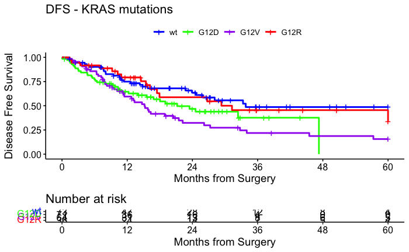

```r
surv_object <-Surv(time = circ_data$DFS_months, event = circ_data$DFS.Event)
KM_curve <- survfit(surv_object ~ KRAS.status, data = circ_data,conf.int=0.95,conf.type="log-log")
ggsurvplot(KM_curve, data = circ_data, pval = FALSE, conf.int = FALSE, risk.table = TRUE, break.time.by=12, palette=c("blue", "green", "purple", "red"), title="DFS - KRAS mutations", ylab= "Disease Free Survival", xlab="Months from Surgery", legend.labs=c("wt","G12D", "G12V", "G12R"), legend.title="")
```

```r
summary(KM_curve, KRAS.status= c(12))
```

```
Call: survfit(formula = surv_object ~ KRAS.status, data = circ_data,
    conf.int = 0.95, conf.type = "log-log")

                KRAS.status=1
  time n.risk n.event survival std.err lower 95% CI upper 95% CI
  1.05     73       1    0.986  0.0136        0.907        0.998
  1.61     71       1    0.972  0.0192        0.894        0.993
  1.94     70       1    0.959  0.0234        0.877        0.986
  2.46     69       1    0.945  0.0269        0.859        0.979
  4.17     66       1    0.930  0.0301        0.841        0.970
  4.57     65       1    0.916  0.0328        0.822        0.961
  5.16     64       1    0.902  0.0353        0.805        0.952
  7.36     60       1    0.887  0.0378        0.786        0.942
  7.62     59       1    0.872  0.0400        0.768        0.931
  7.69     58       1    0.857  0.0421        0.750        0.920
  8.02     57       1    0.842  0.0439        0.732        0.909
  8.05     56       1    0.827  0.0456        0.714        0.898
  9.46     55       1    0.812  0.0472        0.697        0.886
 10.58     53       1    0.796  0.0487        0.680        0.874
 10.78     51       1    0.781  0.0502        0.662        0.862
 10.84     50       1    0.765  0.0516        0.645        0.849
 11.37     48       1    0.749  0.0529        0.627        0.836
 12.58     47       1    0.733  0.0541        0.610        0.823
 14.32     42       1    0.716  0.0556        0.590        0.809
 14.85     41       1    0.698  0.0569        0.571        0.794
 15.77     38       1    0.680  0.0583        0.551        0.779
 22.74     31       1    0.658  0.0604        0.525        0.762
 23.92     29       1    0.635  0.0624        0.500        0.743
 24.67     26       1    0.611  0.0646        0.472        0.723
 25.92     24       1    0.585  0.0668        0.444        0.703
 28.09     20       1    0.556  0.0696        0.410        0.679
 33.31     16       1    0.521  0.0734        0.370        0.653
 33.81     15       1    0.487  0.0763        0.332        0.625

                KRAS.status=2
  time n.risk n.event survival std.err lower 95% CI upper 95% CI
  0.03     71       1    0.986  0.0140        0.904        0.998
  0.95     69       1    0.972  0.0198        0.891        0.993
  1.38     68       1    0.957  0.0241        0.874        0.986
  1.51     67       1    0.943  0.0277        0.855        0.978
```

[output cut: 81 more lines]

```
  1.77     35       1    0.944  0.0382        0.796        0.986
  3.38     34       1    0.917  0.0461        0.763        0.972
  6.93     31       1    0.887  0.0532        0.726        0.956
  9.23     29       1    0.857  0.0595        0.688        0.938
 10.25     27       1    0.825  0.0652        0.650        0.917
 10.91     26       1    0.793  0.0700        0.613        0.896
 14.52     20       1    0.753  0.0769        0.563        0.870
 15.44     19       1    0.714  0.0825        0.517        0.842
 16.20     17       1    0.672  0.0877        0.469        0.811
 17.48     16       1    0.630  0.0917        0.424        0.779
 17.94     15       1    0.588  0.0947        0.382        0.746
 26.71     14       1    0.546  0.0968        0.341        0.711
 29.34     12       1    0.500  0.0988        0.298        0.673
 31.28     11       1    0.455  0.0998        0.257        0.634
 60.00      4       1    0.341  0.1237        0.125        0.574
```

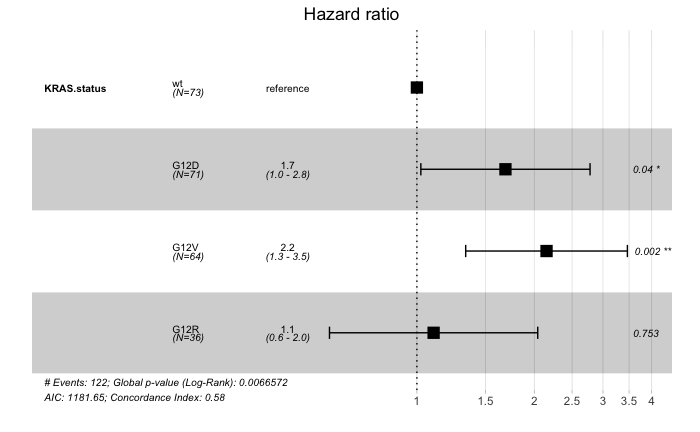

```r
circ_data$KRAS.status <- factor(circ_data$KRAS.status, levels =c("1", "2", "3", "4"), labels =c("wt","G12D", "G12V", "G12R"))
cox_fit <- coxph(surv_object ~ KRAS.status, data=circ_data)
ggforest(cox_fit,data = circ_data)
```

```r
summary(cox_fit)
```

```
Call:
coxph(formula = surv_object ~ KRAS.status, data = circ_data)

  n= 244, number of events= 122

                   coef exp(coef) se(coef)     z Pr(>|z|)
KRAS.statusG12D 0.52284   1.68682  0.25487 2.051  0.04023 *
KRAS.statusG12V 0.76551   2.15009  0.24358 3.143  0.00167 **
KRAS.statusG12R 0.09868   1.10372  0.31369 0.315  0.75308
---
Signif. codes:  0 ‘***’ 0.001 ‘**’ 0.01 ‘*’ 0.05 ‘.’ 0.1 ‘ ’ 1

                exp(coef) exp(-coef) lower .95 upper .95
KRAS.statusG12D     1.687     0.5928    1.0236     2.780
KRAS.statusG12V     2.150     0.4651    1.3339     3.466
KRAS.statusG12R     1.104     0.9060    0.5968     2.041

Concordance= 0.58  (se = 0.026 )
Likelihood ratio test= 12.22  on 3 df,   p=0.007
Wald test            = 11.98  on 3 df,   p=0.007
Score (logrank) test = 12.42  on 3 df,   p=0.006
```